# Maternal Diet Microbiome Analysis

# Workflow

1. **Notebook Set up**
   - Paramaters
   - Packages
   - Common Functions
2. **DII and Microbiome**
   - Normalization and Taxa Abundance
   - Diversity Analysis: Alpha and Beta
   - Network Analysis - NetComi
   - Differential Abundance - metagenomeSeq
3. **Combining the Microbiome and predicted metabolome**
   - PICRUSt2 Analysis
     - Files creation, code to run in terminal and identifying pathways
     - Enriched pathway analysis
   - Gene set enrichment analysis

## 1. Notebook Set up

### 1.1 Notebook Parameters

```r
knitr::opts_chunk$set(echo = TRUE,
                      fig.height = 3,
                      fig.width = 6,
                      fig.path = 'figures',
                      fig.align = "center",
                      fig.cap = TRUE)
```

### 1.2 Required Packages

Use devtools to install packages if problematic

```r
library(captioner)
library(here)
library(tidyverse)
library(devtools)
library(sva)
library(phyloseq)
library(metagenomeSeq)
library(metagMisc)
library(omu)
library(genefilter)
library(PMA)
library(ade4)
library(ggrepel)
library(phyloseqGraphTest)
library(igraph)
library(ggnetwork)
library(heatmaply)
library(pathview)
library(WGCNA)
library(MetaboDiff)
library(factoextra)
library(biomformat)
library(ggtree)
library(data.table)
library(SpiecEasi) #intsall gofotran using https://github.com/coatless-mac/macrtools
library(networkD3)
library(Matrix)
library(pathview)
library(NetCoMi)
library(readxl)
library(circlize)
library(Hmisc)
library(corrplot)
library(ggfortify)
library(clusterProfiler)
library(enrichplot)
library(MicrobiomeProfiler)
library(finalfit)
library(vegan)
library(ggpubr)
```

### 1.3 Commonly used functions

```r
#Write function for linear models
 ################################################
ggplotRegression <- function (fit) {
  require(ggplot2)
  ggplot(fit$model, aes_string(x = names(fit$model)[2], y = names(fit$model)[1])) +
    geom_point() +
    stat_smooth(method = "lm", col = "red") +
    labs(title = paste("Adj R2 = ",signif(summary(fit)$adj.r.squared, 5),
                     "Intercept =",signif(fit$coef[[1]],5 ),
                     " Slope =",signif(fit$coef[[2]], 5),
                     " P =",signif(summary(fit)$coef[2,4], 5)))
}
```

## 2. ASV Microbiome Analysis

**Read in Merged Phyloseq Object**

```r
# Step 1: Read in the saved phyloseq object #######################################################
ps.f <- readRDS(here("Output", "Microbiome_Output", "Phyloseq_Objects", "ps.rds"))
```

[output not shown]

**Demographic info of the study cohort**

```r
# Create Dataframe for plotting
#######################################################
Demo_data <- data.frame(info[,27:40])

# Update insurance type error
#######################################################
Demo_data <- Demo_data %>%
   mutate(Health.Insurance = case_when(Health.Insurance == "Federal Aide_Private" ~ "Federal Aide",
                            Health.Insurance == "Private_Federal Aide" ~ "Federal Aide",
                            Health.Insurance == "Federal Aide" ~ "Federal Aide",
                            Health.Insurance == "Private" ~ "Private")) %>%
   mutate(Relationship.Status = case_when(Relationship.Status == "Seperated/Widowed" ~ "Single",
                            Relationship.Status == "Single" ~ "Single",
                            Relationship.Status == "Married/Relationship" ~ "Married/Relationship"))

# Make a combined Race & Ethnicity Factor with three levels
#######################################################
Demo_data$Race_Ethnicity <- 0

Demo_data <- Demo_data %>%
   mutate(Race_Ethnicity = case_when(Race == "Black" & Ethnicity == "Non-Hispanic/Latino" ~ "Non-Hispanic Black",
                            Race == "White" & Ethnicity == "Hispanic/Latino" ~ "Hispanic")) %>%
  rename("Health_Insurance" = "Health.Insurance") %>%
  rename("Gestational_Weeks" = "Gestational_age") %>%
  rename("Race_Ethnicity" = "Race_Ethnicity") %>%
  rename("Relationship_Status" = "Relationship.Status") %>%
  rename("Planned_Pregnancy" = "Planned.Pregnancy")

Demo_data$Race_Ethnicity <- Demo_data$Race_Ethnicity %>% replace_na("Other/Unreported")

# Get updated dataframe to use for the table plotting
#######################################################
Demo_data <- Demo_data[,-c(2,4,5)]

# Final Crosstable
#######################################################
explanatory = c("DII","Gestational_Weeks","Age", "BMI","Race_Ethnicity",
                "Health_Insurance","Education","Employment","Income",
                "Relationship_Status","Planned_Pregnancy")
dependent = "tertiles"
Demo_data %>%
  summary_factorlist(dependent, explanatory,
  p=TRUE, add_dependent_label=TRUE) -> t1
t1$p <- as.character(round(as.numeric(t1$p),digit=2))
t1$p <- replace(t1$p, is.na(t1$p), "")

knitr::kable(t1, align=c("l", "l", "r", "r", "r"))
```

| Dependent: tertiles |  | Tertile 1 | Tertile 2 | Tertile 3 | p |
| --- | --- | --- | --- | --- | --- |
| DII | Mean (SD) | -2.3 (0.9) | 1.0 (0.9) | 3.4 (0.5) |  |
| Gestational_Weeks | Mean (SD) | 11.2 (3.5) | 11.2 (2.9) | 10.2 (2.7) | 0.59 |
| Age | Mean (SD) | 28.7 (7.8) | 28.6 (5.3) | 30.2 (5.3) | 0.69 |
| BMI | Mean (SD) | 29.0 (7.2) | 30.4 (6.6) | 28.3 (7.5) | 0.7 |
| Race_Ethnicity | Hispanic | 2 (12.5) | 4 (25.0) | 2 (11.8) | 0.35 |
|  | Non-Hispanic Black | 10 (62.5) | 6 (37.5) | 6 (35.3) |  |
|  | Other/Unreported | 4 (25.0) | 6 (37.5) | 9 (52.9) |  |
| Health_Insurance | Federal Aide | 14 (87.5) | 10 (62.5) | 13 (76.5) | 0.26 |
|  | Private | 2 (12.5) | 6 (37.5) | 4 (23.5) |  |
| Education | Above College | 1 (6.2) | 4 (25.0) | 5 (29.4) | 0.34 |
|  | Below College | 6 (37.5) | 4 (25.0) | 7 (41.2) |  |
|  | College | 9 (56.2) | 8 (50.0) | 5 (29.4) |  |
| Employment | Employed Part/Full Time | 11 (68.8) | 8 (50.0) | 10 (58.8) | 0.56 |
|  | Unemployed | 5 (31.2) | 8 (50.0) | 7 (41.2) |  |
| Income | $31-76k | 2 (12.5) | 3 (18.8) | 2 (11.8) | 0.78 |
|  | $76k+ | 1 (6.2) | 3 (18.8) | 2 (11.8) |  |
|  | <$31k | 13 (81.2) | 10 (62.5) | 13 (76.5) |  |
| Relationship_Status | Married/Relationship | 7 (43.8) | 11 (68.8) | 11 (64.7) | 0.3 |
|  | Single | 9 (56.2) | 5 (31.2) | 6 (35.3) |  |
| Planned_Pregnancy | No | 6 (37.5) | 1 (6.2) | 2 (11.8) | 0.17 |
|  | Unreported | 8 (50.0) | 10 (62.5) | 11 (64.7) |  |
|  | Yes | 2 (12.5) | 5 (31.2) | 4 (23.5) |  |

Give a range of EGA for sampling and same for the diet given there is variability it when it was assessed.

```r
#Pull the FFQ sampling dates
################################################################################
FFQ_dates <- read.csv(here("Data", "Blood Data", "Date_FFQ_ID_HGB.csv"))
FFQ_dates <- FFQ_dates[,c(1,4)]

#Pull the micorbiome sampling dates
################################################################################
sample_dates <- read.csv(here("Data", "Microbiome_Data", "Prepartum_Diet_data.csv"))
sample_dates <- sample_dates[,c(2,4,5)]
sample_dates <- sample_dates %>% filter(redcapid %in% info$redcapid & Gestational_age %in% info$Gestational_age)

#Merge by ID
################################################################################
EGA_range <- merge(FFQ_dates, sample_dates, by = "redcapid", all = TRUE)



#Find difference in dates to find FFQ EGA
################################################################################
EGA_range$Visit_Date <- as.Date(EGA_range$Visit_Date, format = "%m/%d/%y")
EGA_range$FFQ_Date <- as.Date(EGA_range$FFQ_Date, format = "%m/%d/%y")

# Calculate the difference in weeks
EGA_range$weeks_difference <- as.numeric(difftime(EGA_range$FFQ_Date, EGA_range$Visit_Date, units = "weeks"))

#This is the FFQ EGA
EGA_range$EGA_FFQ <- round(EGA_range$Gestational_age + EGA_range$weeks_difference)

#Print mean and sd for sampling EGA
column_mean <- mean(as.numeric(EGA_range$Gestational_age), na.rm = TRUE)
column_sd <- sd(as.numeric(EGA_range$Gestational_age), na.rm = TRUE)
cat("Sampling Mean:", column_mean, "\n")
```

```
Sampling Mean: 10.65306
```

```r
cat("Sampling Standard Deviation:", column_sd, "\n")
```

```
Sampling Standard Deviation: 3.085929
```

```r
#Print mean and sd for FFQ EGA
column_mean <- mean(as.numeric(EGA_range$EGA_FFQ), na.rm = TRUE)
column_sd <- sd(as.numeric(EGA_range$EGA_FFQ), na.rm = TRUE)
cat("FFQ Mean:", column_mean, "\n")
```

```
FFQ Mean: 14.79167
```

```r
cat("FFQ Standard Deviation:", column_sd, "\n")
```

```
FFQ Standard Deviation: 5.949999
```

### 2.1 Normalization and Taxa Abundance

Before examining the microbiome profiles, the reads need to be normalized to account for the various library sizes. For these data, we transformed the ASV counts via cumulative-sum-scaling (CSS)

```r
#Step 1: CSS transform the data
####################################################################
css <- phyloseq_transform_css(ps.f, norm= TRUE, log = TRUE)
```

[output not shown]

```r
#Step 2: Taxa agglomerate
####################################################################
ps_phylum <- tax_glom(css, "Phylum")
```

[output not shown]

[output cut: 27 more lines]

[output not shown]

```r
#Step 3: Plot abundances
####################################################################
taxa_names(ps_phylum) <- phyloseq::tax_table(ps_phylum)[, "Phylum"]
```

```
Found more than one class "phylo" in cache; using the first, from namespace 'phyloseq'
Also defined by ‘tidytree’
```

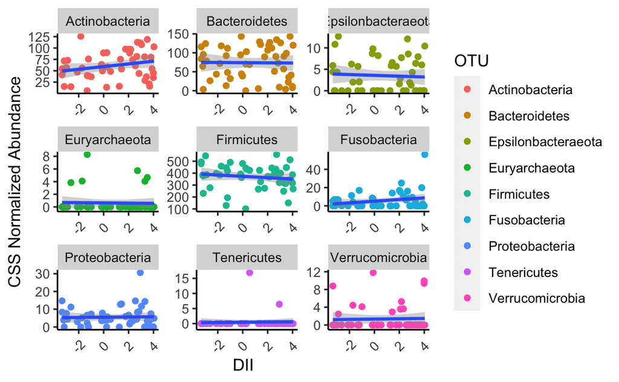

```r
psmelt(ps_phylum) %>%
  ggplot(data = ., aes(x = DII, y = Abundance)) +
    geom_point(aes(color = OTU)) +
  geom_smooth(method='lm') +
    labs(x = "DII", y = "CSS Normalized Abundance", angle = 45) +
    facet_wrap(~ OTU, scales = "free") +
    theme(axis.text.x = element_text(angle = 45, vjust = 0.5, hjust=0.5),
          panel.background = element_blank(),
          axis.line = element_line(colour = "black"))
```

### 2.2 Diversity Analysis

#### 2.2.1 - Alpha Diversity

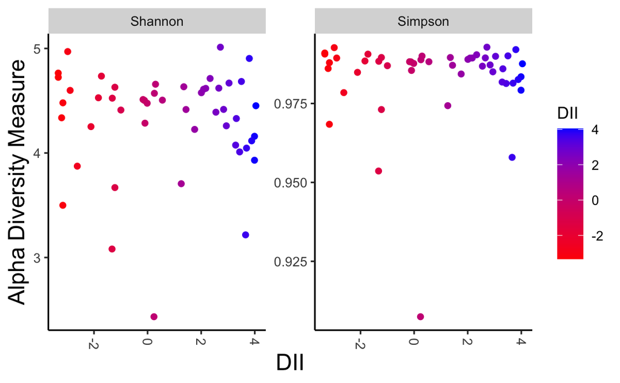

```r
#Step 1: Get alpha diversity measures
###############################################
alpha.div <- estimate_richness(css, split = TRUE, measures = "Shannon")
alpha.div$sd <- sd(alpha.div$Shannon)
alpha.div$mean <- mean(alpha.div$Shannon)

# Step 2: Plot richness
#######################################################

#Diversity by DII
plot_richness(css, x="DII", measures=c("Shannon", "Simpson"), color="DII") +
  scale_colour_gradient(low = "red", high = "blue") +
  theme(panel.grid.major = element_blank(), panel.grid.minor = element_blank(),
        panel.background = element_blank(),
        axis.line = element_line(colour = "black"),
        axis.title = element_text(size = 15))
```

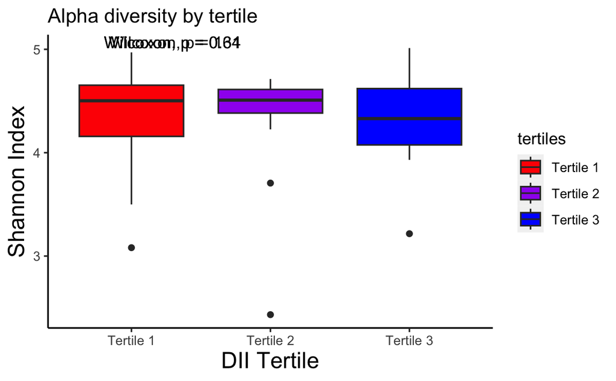

```r
#Step 3: Statistical testing
#######################################################
#Diversity by DII
alpha.div <- merge(alpha.div,info, by=0, all=TRUE)


#Wilcox Rank sum and Boxplot by DII Tertile

ggplot(alpha.div, aes(x = tertiles, y = Shannon, fill=tertiles)) +
   geom_boxplot() +
  scale_fill_manual(values=c("red", "purple","blue")) +
  ggtitle("Alpha diversity by tertile") +
  xlab("DII Tertile") +
  ylab("Shannon Index") +
  stat_compare_means(method = "wilcox.test") +
  theme(panel.grid.major = element_blank(), panel.grid.minor = element_blank(),
        panel.background = element_blank(),
        axis.line = element_line(colour = "black"),
        axis.title = element_text(size = 15))
```

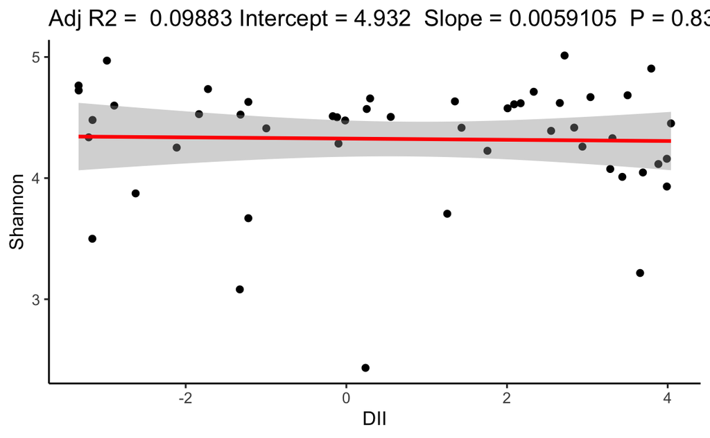

```r
#Linear model of alpha diversity by DII
Alpha_diversity_lm <- lm(Shannon ~ DII + Age + Gestational_age + BMI + FFQ + SampleType, data = alpha.div)

ggplot(Alpha_diversity_lm$model, aes_string(x = names(Alpha_diversity_lm$model)[2],
                                            y = names(Alpha_diversity_lm$model)[1]),
       color = "DII") +
    geom_point() +
    stat_smooth(method = "lm", col = "red") +
    labs(title = paste("Adj R2 = ",signif(summary(Alpha_diversity_lm)$adj.r.squared, 5),
                     "Intercept =",signif(Alpha_diversity_lm$coef[[1]],5 ),
                     " Slope =",signif(Alpha_diversity_lm$coef[[2]], 5),
                     " P =",signif(summary(Alpha_diversity_lm)$coef[2,4], 5))) +
    theme(panel.grid.major = element_blank(), panel.grid.minor = element_blank(),
        panel.background = element_blank(),
        axis.line = element_line(colour = "black"))
```

#### 2.2.2 - Beta Diversity

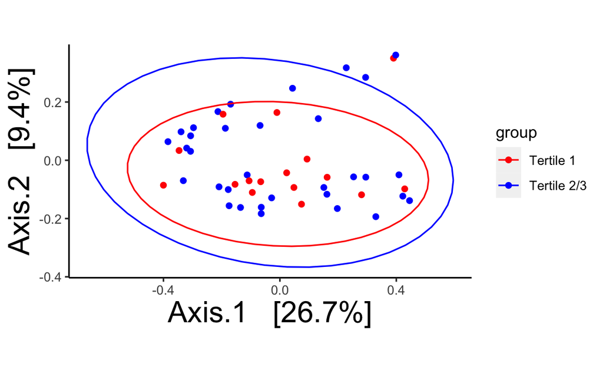

```r
# Method 1: Calculate the Distance Using Bray curtis
###########################################################################
ord <- ordinate(css, "PCoA", "bray", weighted=TRUE)

plot_ordination(css, ord, color="group") +
  #scale_colour_gradient(low = "red", high = "blue") +
  theme(panel.grid.major = element_blank(), panel.grid.minor =
          element_blank(),
        panel.background = element_blank(),
        axis.line = element_line(colour = "black"),
        axis.title = element_text(size = 20)) +
  coord_fixed() +
  stat_ellipse(aes(group = group, color = group)) +
  scale_color_manual(name = "group",
                     values = c("Tertile 1" = "red",
                                "Tertile 2/3" = "blue",
                                labels = c("Tertile 1", "Tertile 2/3")))
```

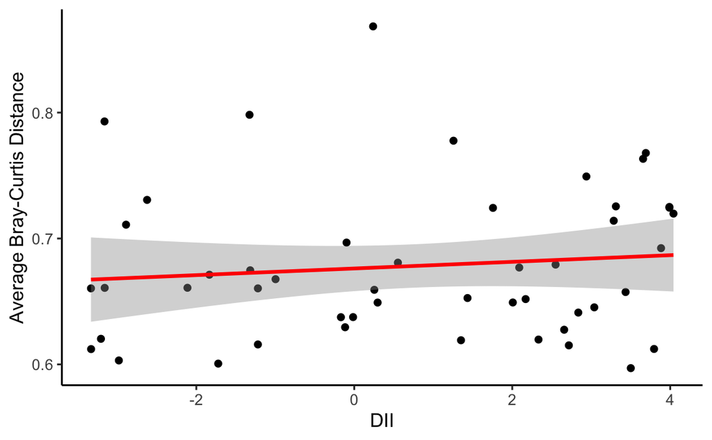

```r
#Plot average distances by DII score
########################################
bray_dist <- as.data.frame(as.matrix(phyloseq::distance(css, "bray")))
bray_dist$Average_dist <- with(bray_dist, rowSums(bray_dist))
bray_dist$Average_dist <- bray_dist$Average_dist/48 # divide by 48 to not include self measure

av_bray_dist <- bray_dist[,49:50]
bray_plotting <- merge(info, av_bray_dist, by = 0, all=TRUE)
bray_plotting <- bray_plotting[,-44]

ggplot(bray_plotting, aes(x=DII, y= Average_dist)) +
  geom_point()  +
    stat_smooth(method = "lm", col = "red") +
  xlab("DII") +
  ylab("Average Bray-Curtis Distance") +
    theme(panel.grid.major = element_blank(), panel.grid.minor = element_blank(),
        panel.background = element_blank(),
        axis.line = element_line(colour = "black"))
```

```r
#Check sig difference between the two groups
########################################
bray_dist <- bray_dist[,-50]

adonis2(bray_dist ~ group + Age + Gestational_age + BMI + SampleType + FFQ, data = bray_plotting)
```

```
Permutation test for adonis under reduced model
Terms added sequentially (first to last)
Permutation: free
Number of permutations: 999

adonis2(formula = bray_dist ~ group + Age + Gestational_age + BMI + SampleType + FFQ, data = bray_plotting)
                Df SumOfSqs      R2      F Pr(>F)
group            1   0.2244 0.01964 0.9563  0.418
Age              1   0.1265 0.01107 0.5392  0.968
Gestational_age  1   0.2049 0.01794 0.8734  0.546
BMI              1   0.1430 0.01251 0.6093  0.901
SampleType       1   0.5140 0.04498 2.1903  0.014 *
FFQ              1   0.3573 0.03127 1.5226  0.093 .
Residual        42   9.8554 0.86258
Total           48  11.4255 1.00000
---
Signif. codes:  0 ‘***’ 0.001 ‘**’ 0.01 ‘*’ 0.05 ‘.’ 0.1 ‘ ’ 1
```

```r
#equality of variance between participants in the tertile 1 versus tertile 2/3
sd_bray_f_data <- bray_dist %>%
  rownames_to_column() %>%
  gather(colname, value, -rowname) %>%
  rename("SampleID" = "rowname") %>%
  rename("target" = "colname")

bray_plotting <- bray_plotting[,c(3,43)]

sd_bray_f_data <- merge(sd_bray_f_data, bray_plotting, by = "SampleID")

# F test for equality of variances
var.test(value ~ group, sd_bray_f_data,
         alternative = "two.sided")
```

```
    F test to compare two variances

data:  value by group
F = 0.91389, num df = 783, denom df = 1616, p-value = 0.1479
alternative hypothesis: true ratio of variances is not equal to 1
95 percent confidence interval:
 0.8109682 1.0325159
sample estimates:
ratio of variances
         0.9138882
```

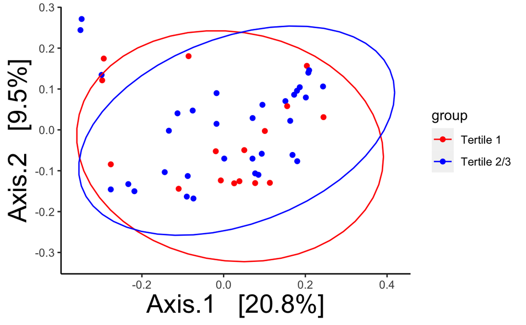

```r
# Method 2: Unifrac distance
###########################################################################
uni <- UniFrac(css, weighted=FALSE, normalized=TRUE, parallel=FALSE, fast=TRUE)

uni.pcoa <- ordinate(css, method="PCoA", distance=uni)

plot_ordination(css, uni.pcoa, color="group") +
  #scale_colour_gradient(low = "red", high = "blue") +
  theme(panel.grid.major = element_blank(), panel.grid.minor =
          element_blank(),
        panel.background = element_blank(),
        axis.line = element_line(colour = "black"),
        axis.title = element_text(size = 20)) +
  coord_fixed() +
  stat_ellipse(aes(group = group, color = group)) +
  scale_color_manual(name = "group",
                     values = c("Tertile 1" = "red",
                                "Tertile 2/3" = "blue",
                                labels = c("Tertile 1", "Tertile 2/3")))
```

### 2.4 metagenomeSeq - CSS and Differential Abundance

Normalize the counts to correct for any difference in read coverage across samples. Using metagenomseq in a three step process. See all the details in this tutorial Method “cumNorm is a normalization method that calculates scaling factors equal to the sum of counts up to a particular quantile.” Basically the normalization uses a scaling factor to put them into quantiles so they are more comparable cite - colorbrewer Subsetted the tertiles so its two factors

#### 2.4.1 Normalization

**All tertiles**. Visualization with heatmaps only

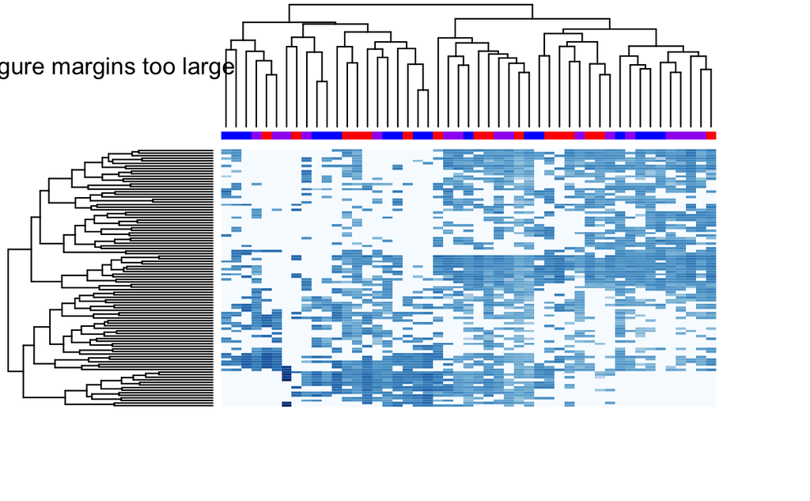

```r
#Step 1: Create MRexperiment Object ##########################################
meta.T1.T2.T3 <- phyloseq_to_metagenomeSeq(css)


#Step 2: Visualize by abundance ##########################################
data2 <- pData(meta.T1.T2.T3)$tertiles

#Make the map colors
heatmapCols2 <- colorRampPalette(brewer.pal(9, "Blues"))(50)

#make the tertile colors
color_vectors <- as.data.frame(meta.T1.T2.T3@phenoData@data[["tertiles"]])
color_vectors$color <- 0
names(color_vectors) <- c("Tertile", "color")

color_vectors <- color_vectors %>%
   mutate(color = case_when(Tertile == "Tertile 1" ~ "red",
                            Tertile == "Tertile 2" ~ "purple",
                            Tertile == "Tertile 3" ~ "blue"))

heatmapColColors2 <- color_vectors$color

plotMRheatmap(obj = meta.T1.T2.T3, n=100, cexRow = 0.4, cexCol = 0.4,
                         trace = "none", col= heatmapCols2, labRow = FALSE,
                         labCol = FALSE, key = TRUE,
                         ColSideColors = heatmapColColors2)
legend("topleft", legend=c("Tertile1","Tertile2", "Tertile3"),
       fill=c("red", "purple","blue"), cex=0.8, box.lty=0)
```

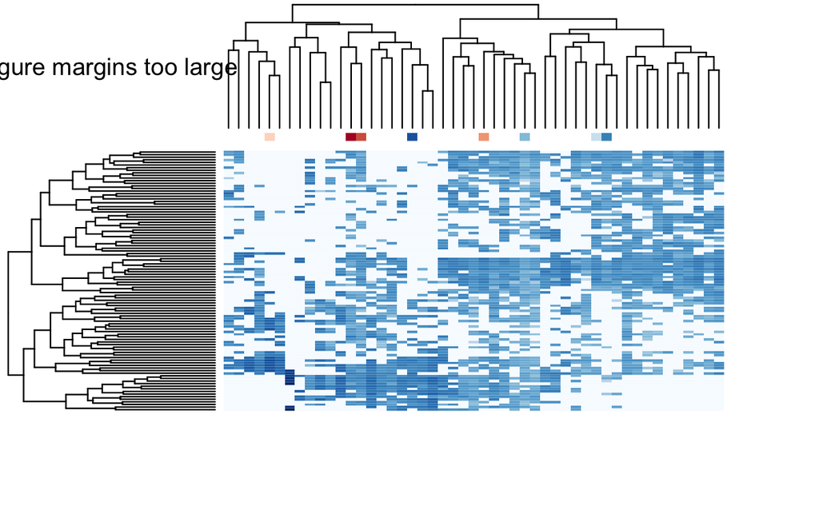

```r
#2c - visualize normalized abundance by DII Continuous score
data3 <- pData(meta.T1.T2.T3)$DII
heatmapColColors3 <- brewer.pal(8,"RdBu")[as.integer(factor(data3))];

heatmapCols3 <- colorRampPalette(brewer.pal(9, "Blues"))(50)

plotMRheatmap(obj = meta.T1.T2.T3, n=100, cexRow = 0.4, cexCol = 0.4,
                         trace = "none", col= heatmapCols3, labRow = FALSE,
                         labCol = FALSE, key = TRUE,
                         ColSideColors = heatmapColColors3)
legend("topright", legend=c("DII score"),
       fill=c(brewer.pal(8,"RdBu")), cex=0.8, box.lty=0)
```

**Make Metagenomseq of Phylum Agglomerated PS**

```r
meta.phylum <- phyloseq_to_metagenomeSeq(ps_phylum)
```

**Data Prep for later**  
Note: Data not corrected by any covariates

```r
# Step 1: Prep the Data ###############################################
corr.counts <- otu_table(css)

corr.c.OTU <- data.frame(corr.counts) #Use later
```

#### 2.4.2 0-inflated Gaussian Model

**Fit the Model** Corrected models by BMI, Age, EGA at during the first trimester visit when data was collected, and need to add Fetal Sex. Currently a lot of NA’s in the Fetal_sex column so we cant use it in the model correction until the rest of them are added back in

```r
# DII , corrected by BMI, Age, EGA, and Sample type and FFQ##########################

#Data Prep - trim low features
rareFeatures = which(rowSums(MRcounts(meta.T1.T2.T3) > 0) < 10)
trim2 = meta.T1.T2.T3[-rareFeatures, ]

#Prep for the Model- Multiple univariate models #####################################
tertile = pData(trim2)$tertile
DII = as.numeric(pData(trim2)$DII)
BMI = as.numeric(pData(trim2)$BMI)
Age = as.numeric(pData(trim2)$Age)
EGA = as.numeric(pData(trim2)$Gestational_age)
FFQ = as.factor(pData(trim2)$FFQ)
SampleType <- as.factor(pData(trim2)$SampleType)
normFactor = normFactors(trim2)
normFactor = log2(normFactor/median(normFactor) + 1)

settings = zigControl(maxit = 10, verbose = TRUE)
modDII = model.matrix(~DII + BMI + Age + EGA + FFQ + SampleType + normFactor)
fitDII = fitZig(obj = trim2, mod = modDII, useCSSoffset = FALSE, control = settings)
```

```
it= 0, nll=68.70, log10(eps+1)=Inf, stillActive=179
it= 1, nll=69.90, log10(eps+1)=0.05, stillActive=85
it= 2, nll=70.46, log10(eps+1)=0.03, stillActive=41
it= 3, nll=71.10, log10(eps+1)=0.02, stillActive=8
it= 4, nll=71.10, log10(eps+1)=0.02, stillActive=4
it= 5, nll=71.21, log10(eps+1)=0.00, stillActive=0
```

```r
#code for filtering to all signficant taxa vs top top
MRcoefsDII <- MRcoefs(fitDII, coef = 2) #default -> gives top 10 taxa

# assign taxanames
MRcoefs_tax <- data.frame(meta.T1.T2.T3@featureData@data)
MRcoefs_tax <- MRcoefs_tax[,-1]
MRcoefs_taxDII <- MRcoefs_tax[row.names(MRcoefs_tax) %in% row.names(MRcoefsDII), ]
MRcoefs_finalDII <- merge(MRcoefsDII, MRcoefs_taxDII, by = 0, all = TRUE)

#Repeat for all the identified taxa to put into the supplemental information
MRcoefsDII_all <- MRcoefs(fitDII, coef = 2, number = 30)
MRcoefsDII_all <- MRcoefsDII_all %>% subset(adjPvalues < 0.050)
MRcoefsDII_all_taxa <- MRcoefs_tax[row.names(MRcoefs_tax) %in% row.names(MRcoefsDII_all), ]
MRcoefsDII_all <- merge(MRcoefsDII_all_taxa, MRcoefsDII_all, by = 0, all = TRUE)
MRcoefsDII_all <- MRcoefsDII_all[,-1]
MRcoefsDII_all <- MRcoefsDII_all %>% dplyr::rename(foldchange = 'DII')

MRcoefsDII_table <- MRcoefsDII_all[order(MRcoefsDII_all$foldchange,decreasing=TRUE),]
MRcoefsDII_table$foldchange <- prettyNum(MRcoefsDII_table$foldchange, format = "g", digits = 2)
MRcoefsDII_table$pvalues <- prettyNum(MRcoefsDII_table$pvalues , format = "g", digits = 2)
MRcoefsDII_table$adjPvalues <- prettyNum(MRcoefsDII_table$adjPvalues , format = "g", digits = 2)
knitr::kable(MRcoefsDII_table)
```

|  | Kingdom | Phylum | Class | Order | Family | Genus | Species | foldchange | pvalues | adjPvalues |
| --- | --- | --- | --- | --- | --- | --- | --- | --- | --- | --- |
| 15 | Bacteria | Firmicutes | Erysipelotrichia | Erysipelotrichales | Erysipelotrichaceae | Solobacterium | moorei | 0.3 | 0.00042 | 0.015 |
| 13 | Bacteria | Firmicutes | Bacilli | Bacillales | Family_XI | Gemella | asaccharolytica | 0.25 | 0.00095 | 0.018 |
| 3 | Bacteria | Actinobacteria | Actinobacteria | Bifidobacteriales | Bifidobacteriaceae | Gardnerella | vaginalis | 0.24 | 0.00012 | 0.0069 |
| 7 | Bacteria | Actinobacteria | Coriobacteriia | Coriobacteriales | Eggerthellaceae | DNF00809 | NA | 0.22 | 4.7e-05 | 0.0042 |
| 9 | Bacteria | Actinobacteria | Actinobacteria | Corynebacteriales | Corynebacteriaceae | Corynebacterium_1 | NA | 0.2 | 0.0012 | 0.018 |
| 5 | Bacteria | Actinobacteria | Coriobacteriia | Coriobacteriales | Atopobiaceae | Atopobium | vaginae | 0.2 | 0.0024 | 0.024 |
| 14 | Bacteria | Firmicutes | Clostridia | Clostridiales | Ruminococcaceae | Ruminococcaceae_UCG-003 | NA | 0.18 | 0.0024 | 0.024 |
| 4 | Bacteria | Actinobacteria | Actinobacteria | Actinomycetales | Actinomycetaceae | Actinomyces | neuii | 0.18 | 0.0025 | 0.024 |
| 12 | Bacteria | Firmicutes | Bacilli | Bacillales | Staphylococcaceae | Staphylococcus | NA | 0.17 | 0.0014 | 0.019 |
| 18 | Bacteria | Firmicutes | Clostridia | Clostridiales | Family_XI | Anaerococcus | NA | -0.16 | 0.00074 | 0.017 |
| 11 | Bacteria | Firmicutes | Erysipelotrichia | Erysipelotrichales | Erysipelotrichaceae | NA | NA | -0.16 | 0.0011 | 0.018 |
| 8 | Bacteria | Firmicutes | Clostridia | Clostridiales | Family_XI | Peptoniphilus | coxii | -0.17 | 0.00099 | 0.018 |
| 16 | Bacteria | Firmicutes | Negativicutes | Selenomonadales | Acidaminococcaceae | Phascolarctobacterium | faecium | -0.18 | 0.0024 | 0.024 |
| 6 | Bacteria | Firmicutes | Clostridia | Clostridiales | Lachnospiraceae | Lachnospiraceae_NK4A136_group | NA | -0.19 | 0.0024 | 0.024 |
| 10 | Bacteria | Firmicutes | Clostridia | Clostridiales | Ruminococcaceae | Faecalibacterium | NA | -0.21 | 0.00056 | 0.017 |
| 1 | Bacteria | Bacteroidetes | Bacteroidia | Bacteroidales | Prevotellaceae | Prevotella | NA | -0.22 | 0.00076 | 0.017 |
| 2 | Bacteria | Bacteroidetes | Bacteroidia | Bacteroidales | Tannerellaceae | Parabacteroides | distasonis | -0.22 | 7.8e-06 | 0.0014 |
| 17 | Bacteria | Firmicutes | Clostridia | Clostridiales | Clostridiaceae_1 | Clostridium_sensu_stricto_1 | NA | -0.32 | 0.00019 | 0.0087 |

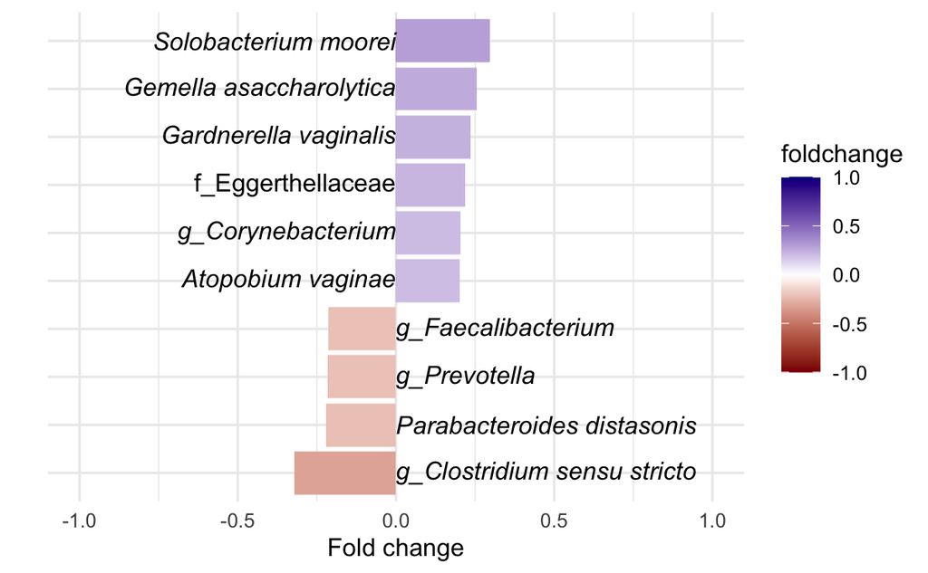

```r
write.csv(MRcoefsDII_table, here("Output", "Microbiome_Output", "DII_enriched_Microbes.csv"))

#Plot the Exported Fits ####################################################

#B) DII   ##########################
MRcoefs_finalDII <- MRcoefs_finalDII %>% dplyr::rename(foldchange = 'DII')
MRcoefs_finalDII$Genus <- make.unique(MRcoefs_finalDII$Genus, sep = '.')

MRcoefs_finalDII$Genus <- factor(MRcoefs_finalDII$Genus,
                              MRcoefs_finalDII$Genus[order(MRcoefs_finalDII$adjPvalues)],
                              ordered=T)

#Add in Plot names with lowest discernable taxa
MRcoefs_finalDII$Plot_names <- c("italic('g_Prevotella')",
                                 "italic('Parabacteroides distasonis')",
                                 "italic('Gardnerella vaginalis')",
                                 "italic('Atopobium vaginae')",
                                 "f_Eggerthellaceae",
                                 "italic('g_Corynebacterium')",
                                 "italic('g_Faecalibacterium')",
                                 "italic('Gemella asaccharolytica')",
                                 "italic('Solobacterium moorei')",
                                 "italic('g_Clostridium sensu stricto')")

#Add directionality based on fold change
MRcoefs_finalDII$just <- ifelse(MRcoefs_finalDII$foldchange < 0,0,1)

#Order by fold chang
MRcoefs_finalDII$Plot_names = with(MRcoefs_finalDII, reorder(Plot_names, foldchange, median))


#Make the plot
ggplot(MRcoefs_finalDII, aes(x=Plot_names, y=foldchange, fill=foldchange)) +
  geom_bar(stat="identity") +
  scale_y_continuous("Fold change", limits = c(-1,1), position="left") +
  scale_x_discrete("", labels = NULL) +
  scale_fill_gradient2(low="darkred", high="darkblue", midpoint=0,
                        limits=c(-1,1)) +
  coord_flip() +
  theme_minimal()+
  geom_text(aes(x=Plot_names, y=0, label=Plot_names), hjust=MRcoefs_finalDII$just, parse = TRUE)
```

```r
#Model C) Phylum Agglommerated - DII , corrected by BMI, Age, EGA, and Fetal Sex
#########################################################################################

#Data Prep
rareFeatures = which(rowSums(MRcounts(meta.phylum) > 0) < 10)
trim2 = meta.phylum[-rareFeatures, ]

#Prep for the Model- Multiple univariate models
tertile = pData(trim2)$tertile
DII = as.numeric(pData(trim2)$DII)
BMI = as.numeric(pData(trim2)$BMI)
HEI = as.numeric(pData(trim2)$HEI2015Score)
Age = as.numeric(pData(trim2)$Age)
EGA = as.numeric(pData(trim2)$Gestational_age)
FFQ = as.factor(pData(trim2)$FFQ)
SampleType <- as.factor(pData(trim2)$SampleType)
normFactor = normFactors(trim2)
normFactor = log2(normFactor/median(normFactor) + 1)


modDII = model.matrix(~DII + BMI + Age + EGA + SampleType + FFQ + normFactor)
fitDII = fitZig(obj = trim2, mod = modDII, useCSSoffset = FALSE, control = settings)
```

```
it= 0, nll=84.39, log10(eps+1)=Inf, stillActive=7
it= 1, nll=84.77, log10(eps+1)=0.04, stillActive=2
it= 2, nll=86.80, log10(eps+1)=-0.00, stillActive=0
```

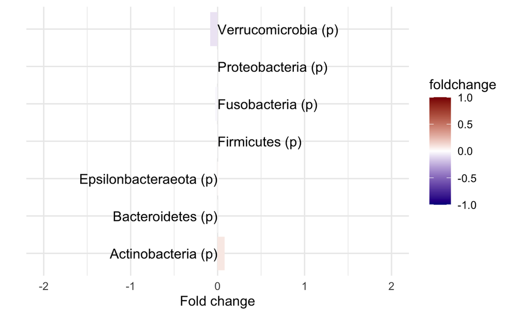

```r
#Export the fit
MRcoefsDII_phylum <- MRcoefs(fitDII, coef = 2)

# assign taxanames
MRcoefs_taxp <- data.frame(tax_table(ps_phylum))
MRcoefs_phylum_tax <- MRcoefs_taxp[row.names(MRcoefs_taxp) %in% row.names(MRcoefsDII_phylum), ]
MRcoefsDII_phylum <- merge(MRcoefsDII_phylum, MRcoefs_phylum_tax, by = 0, all = TRUE)

#Plot the Exported Fits ####################################################

#B) DII   ##########################
MRcoefsDII_phylum <- MRcoefsDII_phylum %>% dplyr::rename(foldchange = 'DII')
MRcoefsDII_phylum$Phylum <- factor(MRcoefsDII_phylum$Phylum,
                              MRcoefsDII_phylum$Phylum[order(MRcoefsDII_phylum$adjPvalues)],
                              ordered=T)
MRcoefsDII_phylum$Plot_names <- c("Actinobacteria (p)", "Bacteroidetes (p)", "Epsilonbacteraeota (p)",
                                  "Firmicutes (p)", "Fusobacteria (p)", "Proteobacteria (p)",
                                  "Verrucomicrobia (p)")
MRcoefsDII_phylum$just <- ifelse(MRcoefsDII_phylum$foldchange < 0,0,1)

MRcoefsDII_phylum <- MRcoefsDII_phylum[order(MRcoefsDII_phylum$foldchange,
                                           decreasing=TRUE, na.last=FALSE),]

ggplot(MRcoefsDII_phylum, aes(x=Plot_names, y=foldchange, fill=foldchange)) +
  geom_bar(stat="identity") +
  scale_y_continuous("Fold change", limits = c(-2,2), position="left") +
  scale_x_discrete("", labels = NULL) +
  scale_fill_gradient2(low="darkblue", high="darkred", midpoint=0,
                        limits=c(-1,1)) +
  coord_flip() +
  theme_minimal()+
  geom_text(aes(x=Plot_names, y=0, label=Plot_names), hjust=MRcoefsDII_phylum$just)
```

## 3. Functional Genome - PICRUSt

### 3.1 - Background on PICRUSt

**PICRUSt Nature Publication**. https://www.nature.com/articles/s41587-020-0548-6

**Workflow**  
Cleaned and trimmed ASVs from the DADA2 analysis were used as inputs in PiCrust2 (analysis)[https://github.com/picrust/picrust2/wiki/PICRUSt2-Tutorial-%28v2.3.0-beta%29#minimum-requirements-to-run-full-tutorial]. This will perfom metagenomic predicitons based on amplicon sequencing data. The main steps are,  
- Place reads into reference tree  
- Hidden-state prediction of gene families  
- Generate metagenome predictions  
- Pathway-level inference

“NSTI scores are simply the average branch length that separates each OTU in your sample from a reference bacterial genome, weighted by the abundance of that OTU in the sample. So the unit for the NSTI score is the same as your reference tree (typically 16S rRNA substitutions/site)” - PiCrust Documentation

There are some key limitations to this analysis that can be read [here](https://github.com/picrust/picrust2/wiki/Key-Limitations). The code to run the PiCrust2.0 using the files created in the beginning of the second half of this analysis (after reading back in the phyloseq object). NOTE: You will need to change the file pathnames. The output files will be stored in the specified output folder.

### 3.2 - Creation of input files for PICRUSt

Phylogenetic Investigation of Communities by Reconstruction of Unobserved States allows you to predict metagenome functional content from marker gene (e.g., 16S rRNA) surveys. In this section, we will generate the required files to run PICRUSt in terminal. [Tutorial](http://picrust.github.io/picrust/tutorials/genome_prediction.html) input

```r
#Step 1: Get fasta ASVs
##########################################################
#get OTUs
otus <- as(otu_table(css),"matrix")

#Change seq headers to asv number (ASV_1, ASV_2...)
asv_seqs <- colnames(t(otus))
asv_headers <- vector(dim(t(otus))[2], mode="character")
for (i in 1:dim(t(otus))[2]) {
  asv_headers[i] <- paste(">ASV", i, sep="_")}

#Create and write out a fasta of our final ASV seqs
asv_fasta <- c(rbind(asv_headers, asv_seqs))
write(asv_fasta, here("Data", "DADA2toPiCrust_Data", "ASVs.fa"))

#Step 2: Get ASVs count table
##########################################################
asv_tab <- (otus)
row.names(asv_tab) <- sub(">", "", asv_headers)
write.table(asv_tab, here("Data", "DADA2toPiCrust_Data", "ASVs_counts.tsv"), sep="\t", quote=F, col.names=NA)


#Step 3: Get tsv (taxa assignments)
##########################################################
asv_tax <- as(tax_table(css),"matrix")
row.names(asv_tax) <- sub(">", "", asv_headers)
write.table(asv_tax, here("Data", "DADA2toPiCrust_Data", "ASVs_taxonomy.tsv"), sep = "\t", quote=F, col.names=NA)

# To merge asv abundance and taxonomy into one file #####################################################
#OTU_TAX_table <- merge(asv_tab, asv_tax, by=0)
#write.table(OTU_TAX_table, here("Data", "DADA2toPiCrust_Data", "OTU_TAX_table.tsv"), sep = "\t", quote=F, col.names=NA)
```

### 3.3 - Terminal Code for running PICRUSt

**Code for creating the Picrust2.0 environment in terminal**  
conda create -n picrust2 -c bioconda -c conda-forge picrust2=2.3.0_b  
conda activate picrust2

**Code for running the pipeline on the appropriate files**  
picrust2_pipeline.py -s /Users/bealab/Desktop/Mat_Diet_noseq_true/Data/DADA2toPiCrust_Data/ASVs.fa -i /Users/bealab/Desktop/Mat_Diet_noseq_true/Data/DADA2toPiCrust_Data/ASVs_counts.tsv -o /Users/bealab/Desktop/Mat_Diet_noseq_true/Data/DADA2toPiCrust_Data/picrust2_out_pipeline -p 1

**NOTES FROM RUNNING PICRUST**  
0 taxa were removed

### 3.4 - Differentially Abundant Pathways & Enzymes

#### 3.4.1 - DII Enriched Pathways

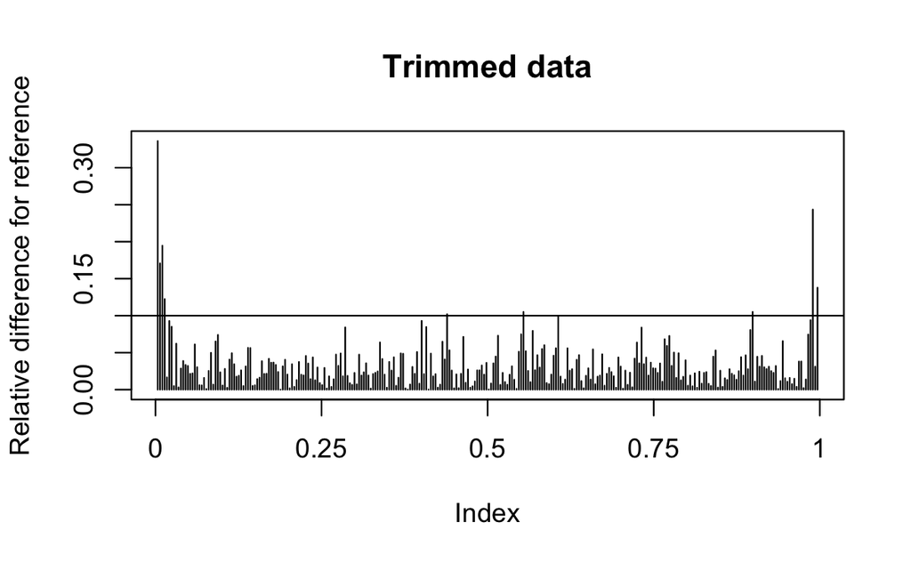

```r
#Step 1: Read in the Data
######################################################################
PiCrust_paths <- read_tsv(here("Data", "DADA2toPiCrust_Data", "picrust2_out_pipeline", "pathways_out", "path_abun_unstrat.tsv"))
#Count data
PiCrust_paths <- column_to_rownames(PiCrust_paths, "pathway")

#Metadata
meta_info <- AnnotatedDataFrame(info)

#Step 2: Create a metagenomeSeq object to perform analysis
######################################################################
PiCrust_meta <- newMRexperiment(counts=PiCrust_paths, phenoData = meta_info)


#Step 3: Run Metagenomseq - fitZig
######################################################################
#Statistical Testing - Make the 0-inflated Gaussian Model
rareFeatures = which(rowSums(MRcounts(PiCrust_meta) > 0) < 10)
trim = PiCrust_meta[-rareFeatures, ]
trimp = cumNormStat(trim, pFlag = TRUE, main = "Trimmed data")
```

```r
trim2 = cumNorm(trim, p = trimp)


#Prep for the Model- Multiple univariate models
DII = as.numeric(pData(trim2)$DII)
BMI = as.numeric(pData(trim2)$BMI)
Age = as.numeric(pData(trim2)$Age)
EGA = as.numeric(pData(trim2)$Gestational_age)
FFQ = as.factor(pData(trim2)$FFQ)
SampleType = as.factor(pData(trim2)$SampleType)
normFactor = normFactors(trim2)
normFactor = log2(normFactor/median(normFactor) + 1)

#Model 1: Compare pathway changes to continuous DII score, corrected by BMI, Age, EGA
######################################################################
mod = model.matrix(~DII + BMI+ Age + EGA+ FFQ + SampleType + normFactor)
settings = zigControl(maxit = 10, verbose = TRUE)
fit = fitZig(obj = trim2, mod = mod, useCSSoffset = FALSE, control = settings)
```

```
it= 0, nll=92.16, log10(eps+1)=Inf, stillActive=291
it= 1, nll=99.26, log10(eps+1)=0.06, stillActive=9
it= 2, nll=99.35, log10(eps+1)=0.01, stillActive=3
it= 3, nll=99.41, log10(eps+1)=0.01, stillActive=1
it= 4, nll=99.46, log10(eps+1)=0.00, stillActive=0
```

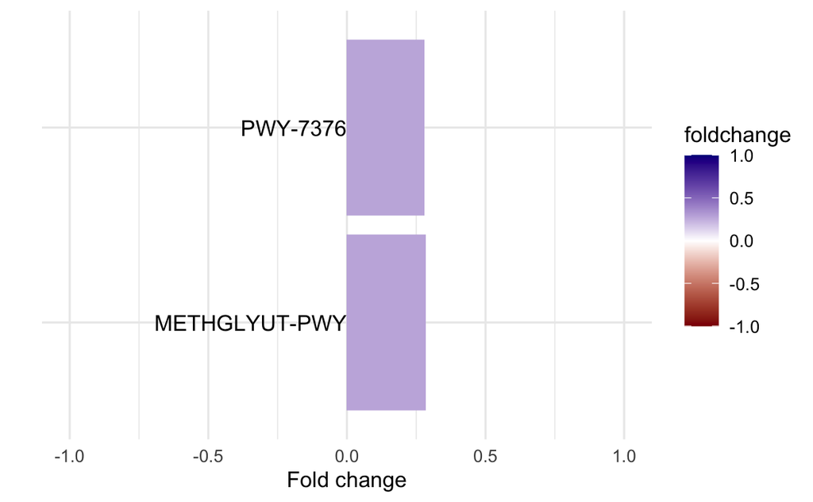

```r
#pull only the significant pathways
MRcoefs <- MRcoefs(fit, coef = 2)
MRcoefs <- MRcoefs %>% subset(adjPvalues < 0.1)


#Plot the Exported Fits
MRcoefs <- MRcoefs %>% dplyr::rename(foldchange = 'DII')
rownames(MRcoefs) <- make.unique(rownames(MRcoefs), sep = '.')
rownames(MRcoefs) <- factor(rownames(MRcoefs),
rownames(MRcoefs)[order(MRcoefs$adjPvalues)], ordered=T)
MRcoefs$just <- ifelse(MRcoefs$foldchange < 0,0,1)

#Order by fold change
rownames(MRcoefs) = with(MRcoefs, reorder(rownames(MRcoefs), foldchange, median))

ggplot(MRcoefs, aes(x=rownames(MRcoefs), y=foldchange, fill=foldchange)) +
  geom_bar(stat="identity") +
  scale_y_continuous("Fold change", limits = c(-1,1), position="left") +
  scale_x_discrete("", labels = NULL) +
  scale_fill_gradient2(low="darkred", high="darkblue", midpoint=0,
                        limits=c(-1,1)) +
  coord_flip() +
  theme_minimal()+
  geom_text(aes(x=rownames(MRcoefs), y=0, label=rownames(MRcoefs)), hjust=MRcoefs$just)
```

##### 3.4.1.1 - Investigation of Enriched Pathway.

```r
# Obtain KOs/sample ID
########################################################################
KO_SID_table <- read_tsv(here::here("Data","DADA2toPiCrust_Data", "picrust2_out_pipeline","KO_metagenome_out", "pred_metagenome_unstrat.tsv"))
KO_SID_table <- as.data.frame(KO_SID_table)
KO_SID_table <- column_to_rownames(KO_SID_table, "function")
```

#### 3.4.2 - DII Enriched KOs (Enzymes)

**Read in diet Data Prep**.

```r
#Step 1: Read in the DII data
########################################################################
DII_parameters <- read.csv(here("Output", "Diet_Output", "DII_parameters_data.csv"))
DII_parameters <- DII_parameters[,-1]

#merge with sample info
info_DII_param <- data.frame(info)
DII_param_info <- merge(info_DII_param, DII_parameters, by="redcapid")
DII_param_info <- DII_param_info %>% column_to_rownames("SampleID")
DII_param_info <- data.frame(DII_param_info)

#Edit column names to remove units
names(DII_param_info) <- gsub("..g.", "", names(DII_param_info))
names(DII_param_info) <- gsub("..mg.", "", names(DII_param_info))
names(DII_param_info) <- gsub("..μg.", "", names(DII_param_info))
names(DII_param_info) <- gsub("..RE.", "", names(DII_param_info))
names(DII_param_info) <- gsub("..kcal.", "", names(DII_param_info))
names(DII_param_info) <- gsub("\\.$", "", names(DII_param_info))

#Rename some of the column names to full
DII_param_info <- DII_param_info %>%
        rename("Energy" = "En",
               "Fiber" = "Fibre",
               "Iron" = "Fe",
               "Magnesium" = "Mg",
               "Selenium" = "Se",
               "Zinc" = "Zn")


ordered_ids <- match(rownames(info), rownames(DII_param_info))

DII_param_info  <- DII_param_info[ordered_ids, ]

#Make Metadata
meta_diet_info <- AnnotatedDataFrame(DII_param_info)
```

**KOs by DII score**

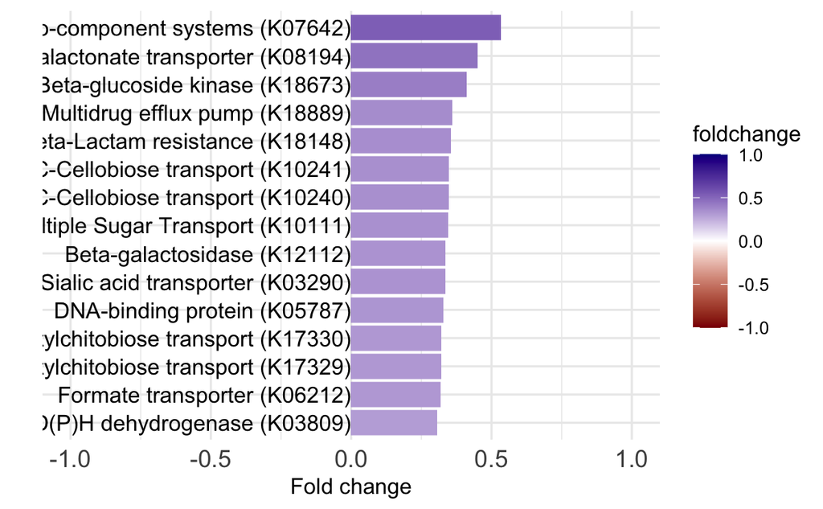

**Export KO Lists**.

```r
write.csv(MR_coefs_GSEA, here("Output", "Microbiome_Output", "Enriched_KOs.csv"))

write.csv(MRcoefs_KO, here("Output", "Microbiome_Output", "FDR_Enriched_KOs.csv"))
```

##### 3.4.2.1 - KOs and DII parameters

Investigation of which DII food parameters are driving the score and their association with the KOs

**Spearman Correlation of Food Parameters**.

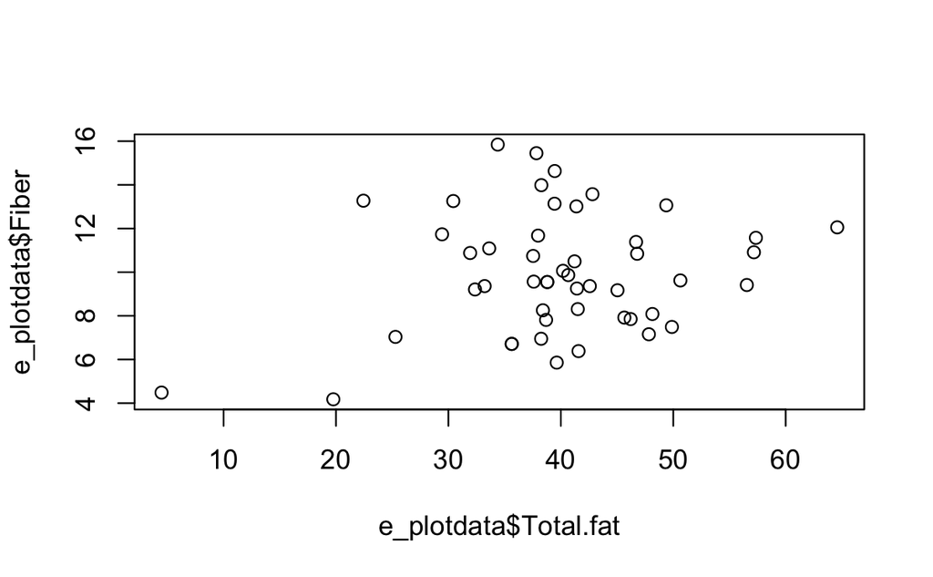

```r
#Step 1; Prep the Data with the appropriate parameters
########################################################################
DII_param_cor <- DII_param_info[,c(26,42:68)]
DII_param_cor <- sapply(DII_param_cor, as.numeric)

plot_data <- as.data.frame(DII_param_cor)

#Formula is nutrient/Kcal intake * 1000
e_plotdata <- plot_data[,]/plot_data$Energy*1000

e_plotdata$Energy <- plot_data$Energy
e_plotdata$DII <- plot_data$DII

plot(e_plotdata$Total.fat, e_plotdata$Fiber)
```

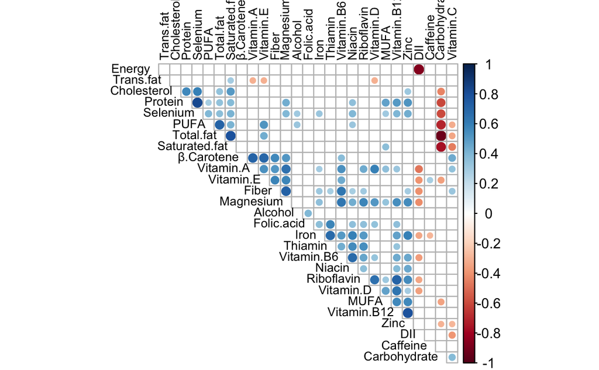

```r
#Step 2: Run the Spearman Correlation and p Test for significance
########################################################################
Cor <- rcorr(as.matrix(e_plotdata), type = "spearman")

#Plot only the significant coefficients
corrplot(Cor$r, type = "upper", order = "hclust",
         p.mat = Cor$P, sig.level = 0.05,
         tl.cex = 0.7, tl.col = "black",
         insig = "blank", cl.p = "r", diag = FALSE)
```

```r
NA
NA
```

**DII Food parameters table**

```r
#Make printable table
DII_param_print <- e_plotdata
DII_param_print$tertiles <- DII_param_info$tertiles
# Final Crosstable
#######################################################
explanatory = c("Alcohol","Vitamin.B12","Vitamin.B6","β.Carotene",
                "Caffeine","Carbohydrate","Cholesterol","Energy","Total.fat",
                "Fiber","Folic.acid","Iron","Magnesium","MUFA","Niacin","Protein",
                "PUFA","Riboflavin","Saturated.fat","Selenium","Thiamin","Trans.fat",
                "Vitamin.A","Vitamin.C","Vitamin.D","Vitamin.E","Zinc")
dependent = "tertiles"
DII_param_print %>%
  summary_factorlist(dependent, explanatory,
  p=TRUE, add_dependent_label=TRUE) -> t1

t1$p <- as.character(round(as.numeric(t1$p),digit=2))
t1$p <- replace(t1$p, is.na(t1$p), "")

knitr::kable(t1, align=c("l", "l", "r", "r", "r"))
```

| Dependent: tertiles |  | Tertile 1 | Tertile 2 | Tertile 3 | p |
| --- | --- | --- | --- | --- | --- |
| Alcohol | Mean (SD) | 0.1 (0.3) | 0.1 (0.2) | 0.1 (0.5) | 0.83 |
| Vitamin.B12 | Mean (SD) | 3.2 (1.1) | 2.9 (1.2) | 2.2 (0.9) | 0.03 |
| Vitamin.B6 | Mean (SD) | 1.1 (0.4) | 1.0 (0.3) | 0.8 (0.2) | 0.02 |
| β.Carotene | Mean (SD) | 1983.5 (1563.7) | 1547.3 (1698.9) | 1491.2 (1104.8) | 0.58 |
| Caffeine | Mean (SD) | 0.0 (0.0) | 0.0 (0.0) | 0.0 (0.0) | 0.43 |
| Carbohydrate | Mean (SD) | 127.5 (25.0) | 129.0 (28.0) | 129.1 (33.9) | 0.98 |
| Cholesterol | Mean (SD) | 136.6 (66.6) | 145.8 (64.5) | 163.6 (113.8) | 0.65 |
| Energy | Mean (SD) | 2988.0 (924.1) | 1801.1 (409.1) | 969.8 (333.8) |  |
| Total.fat | Mean (SD) | 39.5 (9.6) | 40.3 (9.5) | 39.9 (11.4) | 0.98 |
| Fiber | Mean (SD) | 10.9 (2.4) | 10.1 (3.3) | 8.9 (2.2) | 0.11 |
| Folic.acid | Mean (SD) | 168.4 (84.9) | 165.8 (86.0) | 128.7 (75.9) | 0.31 |
| Iron | Mean (SD) | 9.1 (3.4) | 7.9 (2.8) | 6.2 (1.7) | 0.01 |
| Magnesium | Mean (SD) | 171.2 (35.5) | 147.1 (35.7) | 143.2 (40.8) | 0.08 |
| MUFA | Mean (SD) | 0.0 (0.0) | 0.1 (0.0) | 0.0 (0.0) | 0.49 |
| Niacin | Mean (SD) | 11.7 (3.1) | 10.1 (2.1) | 9.0 (2.8) | 0.02 |
| Protein | Mean (SD) | 39.4 (6.1) | 35.6 (7.0) | 35.6 (11.4) | 0.37 |
| PUFA | Mean (SD) | 8.2 (2.3) | 7.9 (2.7) | 8.1 (4.7) | 0.97 |
| Riboflavin | Mean (SD) | 1.3 (0.4) | 1.1 (0.4) | 0.9 (0.3) | 0.02 |
| Saturated.fat | Mean (SD) | 13.5 (3.5) | 14.2 (4.1) | 13.4 (4.3) | 0.82 |
| Selenium | Mean (SD) | 52.2 (10.2) | 49.5 (11.6) | 51.1 (19.5) | 0.87 |
| Thiamin | Mean (SD) | 0.9 (0.3) | 0.8 (0.2) | 0.7 (0.2) | 0.11 |
| Trans.fat | Mean (SD) | 1.7 (0.5) | 1.8 (0.6) | 1.6 (0.7) | 0.75 |
| Vitamin.A | Mean (SD) | 523.2 (192.7) | 437.0 (191.1) | 358.8 (150.4) | 0.04 |
| Vitamin.C | Mean (SD) | 85.5 (42.4) | 71.7 (47.2) | 64.5 (53.1) | 0.45 |
| Vitamin.D | Mean (SD) | 3.9 (1.9) | 3.6 (2.0) | 2.6 (1.7) | 0.1 |
| Vitamin.E | Mean (SD) | 5.1 (2.1) | 3.9 (1.2) | 4.1 (1.8) | 0.13 |
| Zinc | Mean (SD) | 6.5 (1.8) | 5.9 (1.4) | 5.1 (1.4) | 0.04 |

**Check Vitamin B12 status by tertiles and groups**

```r
# Step 1: Print mean Vitamin B12 by tertile
#############################################################################
vitamin_b12_mean <- mean(DII_param_info$Vitamin.B12[DII_param_info$tertiles == "Tertile 1"], na.rm = TRUE)
vitamin_b12_sd <- sd(DII_param_info$Vitamin.B12[DII_param_info$tertiles == "Tertile 1"], na.rm = TRUE)
cat("Mean of Vitamin.B12 for Tertile 1:", vitamin_b12_mean, "\n")
```

```
Mean of Vitamin.B12 for Tertile 1: 9.061722
```

```r
cat("SD of Vitamin.B12 for Tertile 1:", vitamin_b12_sd, "\n")
```

```
SD of Vitamin.B12 for Tertile 1: 2.938537
```

```r
vitamin_b12_mean <- mean(DII_param_info$Vitamin.B12[DII_param_info$tertiles == "Tertile 2"], na.rm = TRUE)
cat("Mean of Vitamin.B12 for Tertile 2:", vitamin_b12_mean, "\n")
```

```
Mean of Vitamin.B12 for Tertile 2: 4.918798
```

```r
vitamin_b12_mean <- mean(DII_param_info$Vitamin.B12[DII_param_info$tertiles == "Tertile 3"], na.rm = TRUE)
cat("Mean of Vitamin.B12 for Tertile 3:", vitamin_b12_mean, "\n")
```

```
Mean of Vitamin.B12 for Tertile 3: 2.156071
```

```r
vitamin_b12_mean <- mean(DII_param_info$Vitamin.B12[DII_param_info$tertiles == "Tertile 2"|
                                                      DII_param_info$tertiles == "Tertile 3"], na.rm = TRUE)
vitamin_b12_sd <- sd(DII_param_info$Vitamin.B12[DII_param_info$tertiles == "Tertile 2"|
                                                      DII_param_info$tertiles == "Tertile 3"], na.rm = TRUE)
cat("Mean of Vitamin.B12 for Tertile 2/3:", vitamin_b12_mean, "\n")
```

```
Mean of Vitamin.B12 for Tertile 2/3: 3.495575
```

```r
cat("SD of Vitamin.B12 for Tertile 2/3:", vitamin_b12_sd, "\n")
```

```
SD of Vitamin.B12 for Tertile 2/3: 1.902597
```

```r
# Step 2: ANOVA to compare means by tertile
#############################################################################
#anova to check difference in vitamin B12
summary(aov(Vitamin.B12 ~ tertiles + Age + EGA, data=DII_param_info))
```

```
            Df Sum Sq Mean Sq F value   Pr(>F)
tertiles     2  396.8  198.38  52.062 2.52e-12 ***
Age          1   12.8   12.85   3.372   0.0731 .
EGA          1    1.9    1.94   0.509   0.4794
Residuals   44  167.7    3.81
---
Signif. codes:  0 ‘***’ 0.001 ‘**’ 0.01 ‘*’ 0.05 ‘.’ 0.1 ‘ ’ 1
```

```r
mean(DII_param_info$Vitamin.B12)
```

```
[1] 5.313093
```

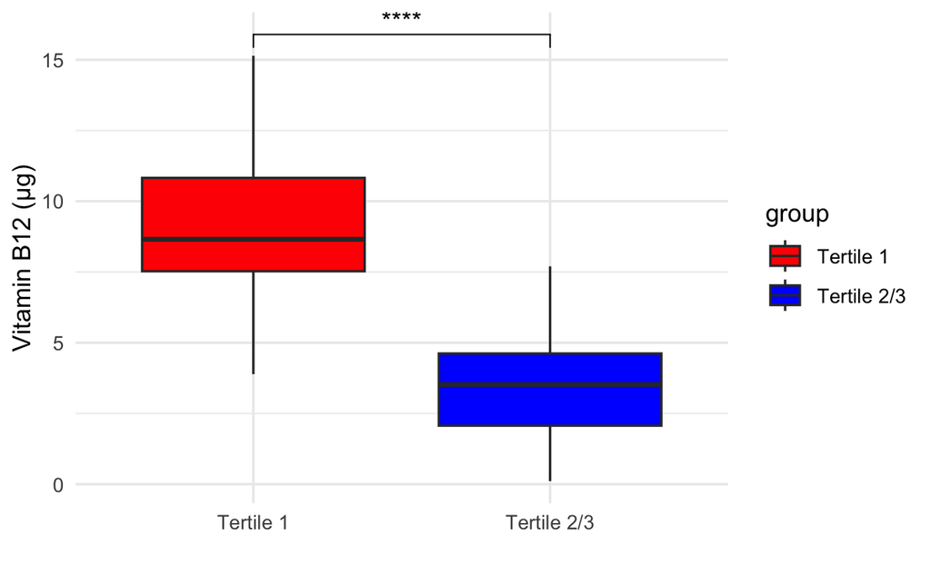

```r
# Step 3: T.Test to compare difference in Vitamin B12 between Tertile 1 and Tertile 2/3
#############################################################################
ggplot(DII_param_info, aes(x = group, y = Vitamin.B12, fill = group)) +
  geom_boxplot() +
  theme_minimal() +
  scale_fill_manual(values=c("red","blue")) +
  stat_compare_means(comparisons = list(c("Tertile 1", "Tertile 2/3")),
                     label = "p.signif", method = "t.test",
                     hide.ns = TRUE, size = 4) +
  xlab("") +
  ylab("Vitamin B12 (μg)")
```

```r
NA
NA
```

**PCA of the Food parameters**.

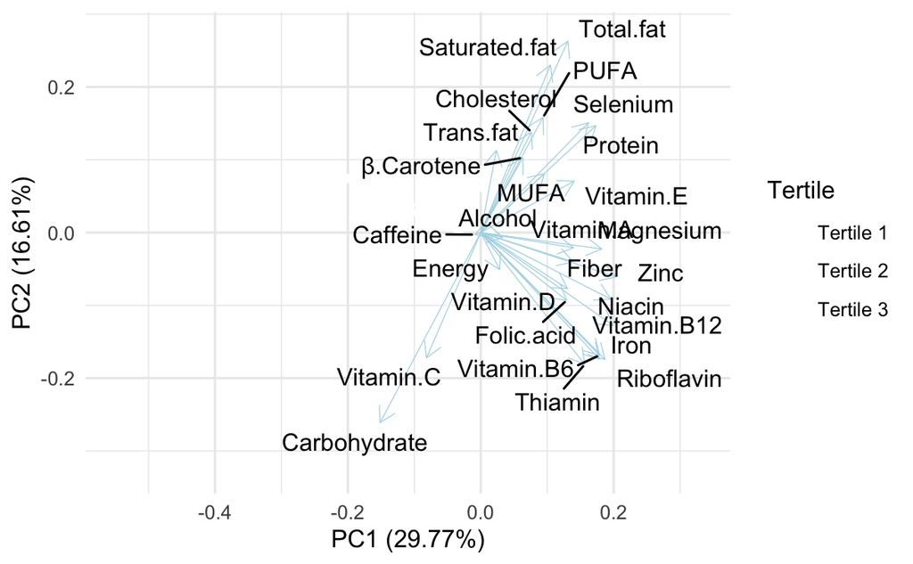

```r
#Step 1; Prep the Data with the appropriate parameters
########################################################################
DII_PCA_data <- e_plotdata[,-1]
DII_PCA_data <- sapply(DII_PCA_data, as.numeric)

#Remove characters after .
DII_PCA_data <- as.data.frame(DII_PCA_data)


#Step 2: Run the PCA
########################################################################
pca_res <- prcomp(DII_PCA_data , scale. = TRUE)

#Add group info
DII_PCA_data$Tertile <- DII_param_info$tertiles

#Plot the PCA
p <- autoplot(pca_res, data = DII_PCA_data,
              loadings = TRUE,
         loadings.colour = 'lightblue',
         colour = "Tertile",
         loadings.label = TRUE,
         loadings.label.size = 3.8,
         loadings.label.colour = "black",
         loadings.label.repel = T) +
         scale_colour_manual(values=c("white", "white","white")) +
  theme_minimal()

p$layers[[2]]$aes_params$size <- 0.2
p
```

```r
#Step 2: Extract Loadings
########################################################################
PCA_loadings <- as.data.frame(pca_res$rotation)
PCA_loadings <- data.frame(PCA_loadings[,c(1:2)])
knitr::kable(
  list(PCA_loadings[1:14,], PCA_loadings[15:27,]),
  booktabs = TRUE
)
```

|  | PC1 | PC2 |
| --- | --- | --- |
| Alcohol | 0.0460357 | -0.0094624 |
| Vitamin.B12 | 0.2785983 | -0.1781937 |
| Vitamin.B6 | 0.2497351 | -0.2352097 |
| β.Carotene | 0.0883943 | 0.1436715 |
| Caffeine | -0.0121466 | -0.0038882 |
| Carbohydrate | -0.2115887 | -0.3645342 |
| Cholesterol | 0.1062459 | 0.1928506 |
| Energy | 0.0396350 | -0.0708762 |
| Total.fat | 0.1830451 | 0.3670900 |
| Fiber | 0.1945638 | -0.0561457 |
| Folic.acid | 0.1805288 | -0.1299560 |
| Iron | 0.2493900 | -0.2427864 |
| Magnesium | 0.2543392 | -0.0313597 |
| MUFA | 0.1337164 | 0.1128903 |

|  | PC1 | PC2 |
| --- | --- | --- |
| Niacin | 0.2733640 | -0.1277476 |
| Protein | 0.2417760 | 0.2049031 |
| PUFA | 0.1307838 | 0.2206555 |
| Riboflavin | 0.2611756 | -0.2433596 |
| Saturated.fat | 0.1464062 | 0.3211840 |
| Selenium | 0.2263553 | 0.2108001 |
| Thiamin | 0.2184725 | -0.2527567 |
| Trans.fat | 0.0326818 | 0.1574118 |
| Vitamin.A | 0.1948910 | -0.0290223 |
| Vitamin.C | -0.1140070 | -0.2402471 |
| Vitamin.D | 0.1821681 | -0.1074107 |
| Vitamin.E | 0.1962415 | 0.0988103 |
| Zinc | 0.2845073 | -0.0852594 |

**MetagenomSeq of KOs & Food**

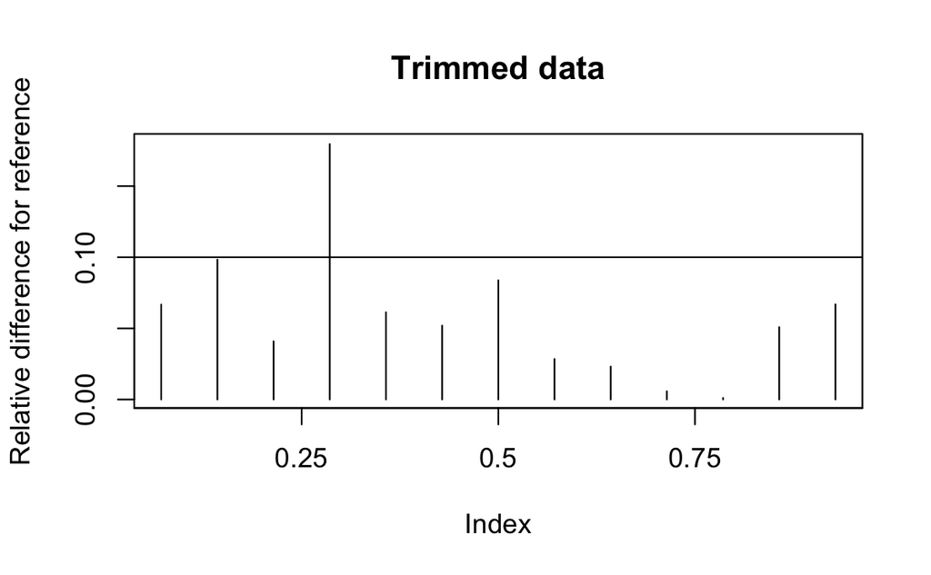

```r
# Step 1: Make a KO Table
#######################################################################################
#Filter to only significiant KOs
sig_KO_vector <- rownames(MRcoefs_KO_top)
Enriched_KOs <- KO_SID_table[sig_KO_vector, ]

#z-score the food paramters
DII_param_info_z <- DII_param_info
DII_param_info_z[,42:68] <- scale(DII_param_info_z[,42:68])
meta_diet_info_z <- AnnotatedDataFrame(DII_param_info_z)

#MetagenomeSeq object of only significantly enriched KOs
Enriched_KOs_meta <- newMRexperiment(counts=Enriched_KOs, phenoData = meta_diet_info_z)


#Step 2: Run Metagenomseq - fitZig
######################################################################################
#Statistical Testing - Make the 0-inflated Gaussian Model
rareFeatures = which(colSums(MRcounts(Enriched_KOs_meta)) == 0)
trim = Enriched_KOs_meta[,-rareFeatures]
trimp = cumNormStat(trim, pFlag = TRUE, main = "Trimmed data")
```

```r
trim2 = cumNorm(trim, p = trimp)

#Prep for the Model
DII = as.numeric(pData(trim2)$DII)
BMI = as.numeric(pData(trim2)$BMI)
Age = as.numeric(pData(trim2)$Age)
EGA = as.numeric(pData(trim2)$Gestational)
FFQ = as.factor(pData(trim2)$FFQ)
SampleType <- as.factor(pData(trim2)$SampleType)
Alcohol = as.numeric(pData(trim2)$Alcohol)
Vitamin.B12 = as.numeric(pData(trim2)$Vitamin.B12)
Vitamin.B6 = as.numeric(pData(trim2)$Vitamin.B6)
β.Carotene = as.numeric(pData(trim2)$β.Carotene)
Caffeine = as.numeric(pData(trim2)$Caffeine)
Carbohydrate = as.numeric(pData(trim2)$Carbohydrate)
Cholesterol = as.numeric(pData(trim2)$Cholesterol)
Energy = as.numeric(pData(trim2)$Energy)
Total.fat = as.numeric(pData(trim2)$Total.fat)
Fiber = as.numeric(pData(trim2)$Fiber)
Folic.acid = as.numeric(pData(trim2)$Folic.acid)
Iron = as.numeric(pData(trim2)$Iron)
Magnesium = as.numeric(pData(trim2)$Magnesium)
MUFA = as.numeric(pData(trim2)$MUFA)
Nicain = as.numeric(pData(trim2)$Niacin)
Protein = as.numeric(pData(trim2)$Protein)
PUFA = as.numeric(pData(trim2)$PUFA)
Riboflavin = as.numeric(pData(trim2)$Riboflavin)
Saturated.fat = as.numeric(pData(trim2)$Saturated.fat)
Selenium = as.numeric(pData(trim2)$Selenium)
Thiamin = as.numeric(pData(trim2)$Thiamin)
Trans.fat = as.numeric(pData(trim2)$Trans.fat)
Vitamin.A = as.numeric(pData(trim2)$Vitamin.A)
Vitamin.C = as.numeric(pData(trim2)$Vitamin.C)
Vitamin.D = as.numeric(pData(trim2)$Vitamin.D)
Vitamin.E = as.numeric(pData(trim2)$Vitamin.E)
Zinc = as.numeric(pData(trim2)$Zinc)

normFactor = normFactors(trim2)
normFactor = log2(normFactor/median(normFactor) + 1)
```

```r
# Alcohol
########################################################################
mod = model.matrix(~Alcohol + BMI + Age + EGA + FFQ + SampleType + normFactor)
settings = zigControl(maxit = 10, verbose = TRUE)
fit = fitZig(obj = trim2, mod = mod, useCSSoffset = FALSE, control = settings)
```

```
it= 0, nll=55.94, log10(eps+1)=Inf, stillActive=15
it= 1, nll=57.88, log10(eps+1)=0.02, stillActive=6
it= 2, nll=58.19, log10(eps+1)=0.01, stillActive=2
it= 3, nll=59.74, log10(eps+1)=0.01, stillActive=0
```

```r
#pull only the significant enzymes
Alc_sig <- MRcoefs(fit, coef = 2, number = 15)
Alc_sig <- mutate(Alc_sig,Alcohol=if_else(adjPvalues>0.05, 0, Alcohol))
Alc_sig <- Alc_sig[,-c(2,3)]

# Vitamin B12
########################################################################
mod = model.matrix(~Vitamin.B12 + BMI + Age + EGA + FFQ + SampleType + normFactor)
settings = zigControl(maxit = 10, verbose = TRUE)
fit = fitZig(obj = trim2, mod = mod, useCSSoffset = FALSE, control = settings)
```

```
it= 0, nll=55.88, log10(eps+1)=Inf, stillActive=15
it= 1, nll=57.75, log10(eps+1)=0.02, stillActive=6
it= 2, nll=58.10, log10(eps+1)=0.03, stillActive=2
it= 3, nll=59.79, log10(eps+1)=0.01, stillActive=0
```

```r
#pull only the significant enzymes
VB12_sig <- MRcoefs(fit, coef = 2, number = 15)
VB12_sig <- mutate(VB12_sig, Vitamin.B12=if_else(adjPvalues>0.05, 0, Vitamin.B12))
VB12_sig <- VB12_sig[,-c(2,3)]

# Vitamin B6
########################################################################
mod = model.matrix(~Vitamin.B6 + BMI + Age + EGA + FFQ + SampleType + normFactor)
settings = zigControl(maxit = 10, verbose = TRUE)
fit = fitZig(obj = trim2, mod = mod, useCSSoffset = FALSE, control = settings)
```

```
it= 0, nll=55.90, log10(eps+1)=Inf, stillActive=15
it= 1, nll=57.57, log10(eps+1)=0.02, stillActive=6
it= 2, nll=57.39, log10(eps+1)=0.04, stillActive=2
it= 3, nll=59.03, log10(eps+1)=0.01, stillActive=0
```

```r
#pull only the significant enzymes
VB6_sig <- MRcoefs(fit, coef = 2, number = 15)
VB6_sig <- mutate(VB6_sig, Vitamin.B6=if_else(adjPvalues>0.05, 0, Vitamin.B6))
VB6_sig <- VB6_sig[,-c(2,3)]


# β.Carotene
########################################################################
mod = model.matrix(~β.Carotene + BMI + Age + EGA + FFQ + SampleType + normFactor)
settings = zigControl(maxit = 10, verbose = TRUE)
fit = fitZig(obj = trim2, mod = mod, useCSSoffset = FALSE, control = settings)
```

```
it= 0, nll=55.94, log10(eps+1)=Inf, stillActive=15
it= 1, nll=57.74, log10(eps+1)=0.02, stillActive=6
it= 2, nll=57.51, log10(eps+1)=0.03, stillActive=2
it= 3, nll=58.43, log10(eps+1)=0.02, stillActive=1
it= 4, nll=59.31, log10(eps+1)=0.01, stillActive=0
```

```r
#pull only the significant enzymes
β.Car_sig <- MRcoefs(fit, coef = 2, number = 15)
β.Car_sig <- mutate(β.Car_sig, β.Carotene=if_else(adjPvalues>0.05, 0, β.Carotene))
β.Car_sig <- β.Car_sig[,-c(2,3)]


# Caffeine
########################################################################
mod = model.matrix(~Caffeine + BMI + Age + EGA + FFQ + SampleType + normFactor)
settings = zigControl(maxit = 10, verbose = TRUE)
fit = fitZig(obj = trim2, mod = mod, useCSSoffset = FALSE, control = settings)
```

```
it= 0, nll=55.97, log10(eps+1)=Inf, stillActive=15
it= 1, nll=57.63, log10(eps+1)=0.02, stillActive=6
it= 2, nll=57.71, log10(eps+1)=0.03, stillActive=2
it= 3, nll=59.51, log10(eps+1)=0.02, stillActive=0
```

```r
#pull only the significant enzymes
Caff_sig <- MRcoefs(fit, coef = 2, number = 15)
Caff_sig <- mutate(Caff_sig, Caffeine=if_else(adjPvalues>0.05, 0, Caffeine))
Caff_sig <- Caff_sig[,-c(2,3)]



# Carbohydrate
########################################################################
mod = model.matrix(~Carbohydrate + BMI + Age + EGA + FFQ + SampleType + normFactor)
settings = zigControl(maxit = 10, verbose = TRUE)
fit = fitZig(obj = trim2, mod = mod, useCSSoffset = FALSE, control = settings)
```

```
it= 0, nll=55.85, log10(eps+1)=Inf, stillActive=15
it= 1, nll=57.64, log10(eps+1)=0.03, stillActive=6
it= 2, nll=57.52, log10(eps+1)=0.03, stillActive=2
it= 3, nll=59.52, log10(eps+1)=0.01, stillActive=0
```

```r
#pull only the significant enzymes
Carb_sig <- MRcoefs(fit, coef = 2, number = 15)
Carb_sig <- mutate(Carb_sig, Carbohydrate=if_else(adjPvalues>0.05, 0, Carbohydrate))
Carb_sig <- Carb_sig[,-c(2,3)]


# Cholesterol
########################################################################
mod = model.matrix(~Cholesterol + BMI + Age + EGA + FFQ + SampleType +  normFactor)
settings = zigControl(maxit = 10, verbose = TRUE)
fit = fitZig(obj = trim2, mod = mod, useCSSoffset = FALSE, control = settings)
```

```
it= 0, nll=55.70, log10(eps+1)=Inf, stillActive=15
it= 1, nll=57.78, log10(eps+1)=0.02, stillActive=5
it= 2, nll=58.71, log10(eps+1)=0.03, stillActive=1
it= 3, nll=60.00, log10(eps+1)=-0.00, stillActive=0
```

```r
#pull only the significant enzymes
Chol_sig <- MRcoefs(fit, coef = 2, number = 15)
Chol_sig <- mutate(Chol_sig, Cholesterol=if_else(adjPvalues>0.05, 0, Cholesterol))
Chol_sig <- Chol_sig[,-c(2,3)]


# Energy
########################################################################
mod = model.matrix(~Energy + BMI + Age + EGA + FFQ + SampleType + normFactor)
settings = zigControl(maxit = 10, verbose = TRUE)
fit = fitZig(obj = trim2, mod = mod, useCSSoffset = FALSE, control = settings)
```

```
it= 0, nll=55.86, log10(eps+1)=Inf, stillActive=15
it= 1, nll=57.75, log10(eps+1)=0.03, stillActive=6
it= 2, nll=57.70, log10(eps+1)=0.04, stillActive=2
it= 3, nll=59.57, log10(eps+1)=0.01, stillActive=0
```

```r
#pull only the significant enzymes
Energy_sig <- MRcoefs(fit, coef = 2, number = 15)
Energy_sig <- mutate(Energy_sig, Energy=if_else(adjPvalues>0.05, 0, Energy))
Energy_sig <- Energy_sig[,-c(2,3)]



# Total.fat
########################################################################
mod = model.matrix(~Total.fat + BMI + Age + EGA + FFQ + SampleType + normFactor)
settings = zigControl(maxit = 10, verbose = TRUE)
fit = fitZig(obj = trim2, mod = mod, useCSSoffset = FALSE, control = settings)
```

```
it= 0, nll=55.93, log10(eps+1)=Inf, stillActive=15
it= 1, nll=57.93, log10(eps+1)=0.02, stillActive=6
it= 2, nll=57.93, log10(eps+1)=0.04, stillActive=2
it= 3, nll=59.23, log10(eps+1)=0.01, stillActive=1
it= 4, nll=59.92, log10(eps+1)=0.02, stillActive=0
```

```r
#pull only the significant enzymes
T.fat_sig <- MRcoefs(fit, coef = 2, number = 15)
T.fat_sig <- mutate(T.fat_sig, Total.fat=if_else(adjPvalues>0.05, 0, Total.fat))
T.fat_sig <- T.fat_sig[,-c(2,3)]


# Fiber
########################################################################
mod = model.matrix(~Fiber + BMI + Age + EGA + FFQ + SampleType + normFactor)
settings = zigControl(maxit = 10, verbose = TRUE)
fit = fitZig(obj = trim2, mod = mod, useCSSoffset = FALSE, control = settings)
```

```
it= 0, nll=56.02, log10(eps+1)=Inf, stillActive=15
it= 1, nll=57.65, log10(eps+1)=0.03, stillActive=6
it= 2, nll=57.28, log10(eps+1)=0.04, stillActive=2
it= 3, nll=58.92, log10(eps+1)=0.01, stillActive=1
it= 4, nll=59.51, log10(eps+1)=0.01, stillActive=0
```

```r
#pull only the significant enzymes
Fib_sig <- MRcoefs(fit, coef = 2, number = 15)
Fib_sig <- mutate(Fib_sig, Fiber=if_else(adjPvalues>0.05, 0, Fiber))
Fib_sig <- Fib_sig[,-c(2,3)]



# Folic.acid
########################################################################
mod = model.matrix(~Folic.acid + BMI + Age + EGA + FFQ + SampleType + normFactor)
settings = zigControl(maxit = 10, verbose = TRUE)
fit = fitZig(obj = trim2, mod = mod, useCSSoffset = FALSE, control = settings)
```

```
it= 0, nll=55.78, log10(eps+1)=Inf, stillActive=15
it= 1, nll=57.63, log10(eps+1)=0.02, stillActive=6
it= 2, nll=57.76, log10(eps+1)=0.03, stillActive=2
it= 3, nll=58.99, log10(eps+1)=0.01, stillActive=1
it= 4, nll=59.78, log10(eps+1)=0.01, stillActive=0
```

```r
#pull only the significant enzymes
Folic_sig <- MRcoefs(fit, coef = 2, number = 15)
Folic_sig <- mutate(Folic_sig, Folic.acid=if_else(adjPvalues>0.05, 0, Folic.acid))
Folic_sig <- Folic_sig[,-c(2,3)]



# Iron
########################################################################
mod = model.matrix(~Iron + BMI + Age + EGA + FFQ + SampleType + normFactor)
settings = zigControl(maxit = 10, verbose = TRUE)
fit = fitZig(obj = trim2, mod = mod, useCSSoffset = FALSE, control = settings)
```

```
it= 0, nll=55.91, log10(eps+1)=Inf, stillActive=15
it= 1, nll=57.82, log10(eps+1)=0.02, stillActive=6
it= 2, nll=57.86, log10(eps+1)=0.04, stillActive=2
it= 3, nll=59.98, log10(eps+1)=0.01, stillActive=0
```

```r
#pull only the significant enzymes
Iron_sig <- MRcoefs(fit, coef = 2, number = 15)
Iron_sig <- mutate(Iron_sig, Iron=if_else(adjPvalues>0.05, 0, Iron))
Iron_sig <- Iron_sig[,-c(2,3)]


# Magnesium
########################################################################
mod = model.matrix(~Magnesium + BMI + Age + EGA + FFQ + SampleType + normFactor)
settings = zigControl(maxit = 10, verbose = TRUE)
fit = fitZig(obj = trim2, mod = mod, useCSSoffset = FALSE, control = settings)
```

```
it= 0, nll=55.90, log10(eps+1)=Inf, stillActive=15
it= 1, nll=57.54, log10(eps+1)=0.03, stillActive=6
it= 2, nll=57.39, log10(eps+1)=0.04, stillActive=2
it= 3, nll=59.02, log10(eps+1)=0.01, stillActive=1
it= 4, nll=59.70, log10(eps+1)=0.01, stillActive=0
```

```r
#pull only the significant enzymes
Mag_sig <- MRcoefs(fit, coef = 2, number = 15)
Mag_sig <- mutate(Mag_sig, Magnesium=if_else(adjPvalues>0.05, 0, Magnesium))
Mag_sig <- Mag_sig[,-c(2,3)]



# MUFA
########################################################################
mod = model.matrix(~MUFA + BMI + Age + EGA + FFQ + SampleType + normFactor)
settings = zigControl(maxit = 10, verbose = TRUE)
fit = fitZig(obj = trim2, mod = mod, useCSSoffset = FALSE, control = settings)
```

```
it= 0, nll=55.93, log10(eps+1)=Inf, stillActive=15
it= 1, nll=57.87, log10(eps+1)=0.02, stillActive=6
it= 2, nll=57.97, log10(eps+1)=0.03, stillActive=2
it= 3, nll=59.52, log10(eps+1)=0.01, stillActive=0
```

```r
#pull only the significant enzymes
MUFA_sig <- MRcoefs(fit, coef = 2, number = 15)
MUFA_sig <- mutate(MUFA_sig, MUFA=if_else(adjPvalues>0.05, 0, MUFA))
MUFA_sig <- MUFA_sig[,-c(2,3)]


# Nicain
########################################################################
mod = model.matrix(~Nicain + BMI + Age + EGA + FFQ + SampleType + normFactor)
settings = zigControl(maxit = 10, verbose = TRUE)
fit = fitZig(obj = trim2, mod = mod, useCSSoffset = FALSE, control = settings)
```

```
it= 0, nll=55.85, log10(eps+1)=Inf, stillActive=15
it= 1, nll=57.64, log10(eps+1)=0.02, stillActive=6
it= 2, nll=57.39, log10(eps+1)=0.04, stillActive=2
it= 3, nll=59.03, log10(eps+1)=0.01, stillActive=1
it= 4, nll=59.61, log10(eps+1)=0.01, stillActive=0
```

```r
#pull only the significant enzymes
Nicain_sig <- MRcoefs(fit, coef = 2, number = 15)
Nicain_sig <- mutate(Nicain_sig, Nicain=if_else(adjPvalues>0.05, 0, Nicain))
Nicain_sig <- Nicain_sig[,-c(2,3)]


# Protein
########################################################################
mod = model.matrix(~Protein + BMI + Age + EGA + FFQ + SampleType + normFactor)
settings = zigControl(maxit = 10, verbose = TRUE)
fit = fitZig(obj = trim2, mod = mod, useCSSoffset = FALSE, control = settings)
```

```
it= 0, nll=55.87, log10(eps+1)=Inf, stillActive=15
it= 1, nll=57.88, log10(eps+1)=0.02, stillActive=6
it= 2, nll=57.94, log10(eps+1)=0.04, stillActive=2
it= 3, nll=59.72, log10(eps+1)=0.01, stillActive=1
it= 4, nll=60.46, log10(eps+1)=0.02, stillActive=0
```

```r
#pull only the significant enzymes
Protein_sig <- MRcoefs(fit, coef = 2, number = 15)
Protein_sig <- mutate(Protein_sig, Protein=if_else(adjPvalues>0.05, 0, Protein))
Protein_sig <- Protein_sig[,-c(2,3)]


# PUFA
########################################################################
mod = model.matrix(~PUFA + BMI + Age + EGA + FFQ + SampleType + normFactor)
settings = zigControl(maxit = 10, verbose = TRUE)
fit = fitZig(obj = trim2, mod = mod, useCSSoffset = FALSE, control = settings)
```

```
it= 0, nll=55.98, log10(eps+1)=Inf, stillActive=15
it= 1, nll=57.93, log10(eps+1)=0.02, stillActive=6
it= 2, nll=57.90, log10(eps+1)=0.04, stillActive=2
it= 3, nll=59.31, log10(eps+1)=0.01, stillActive=1
it= 4, nll=59.99, log10(eps+1)=0.02, stillActive=0
```

```r
#pull only the significant enzymes
PUFA_sig <- MRcoefs(fit, coef = 2, number = 15)
PUFA_sig <- mutate(PUFA_sig, PUFA=if_else(adjPvalues>0.05, 0, PUFA))
PUFA_sig <- PUFA_sig[,-c(2,3)]


# Riboflavin
########################################################################
mod = model.matrix(~Riboflavin + BMI + Age + EGA + FFQ + SampleType + normFactor)
settings = zigControl(maxit = 10, verbose = TRUE)
fit = fitZig(obj = trim2, mod = mod, useCSSoffset = FALSE, control = settings)
```

```
it= 0, nll=55.82, log10(eps+1)=Inf, stillActive=15
it= 1, nll=57.54, log10(eps+1)=0.03, stillActive=6
it= 2, nll=57.46, log10(eps+1)=0.04, stillActive=2
it= 3, nll=59.44, log10(eps+1)=0.01, stillActive=0
```

```r
#pull only the significant enzymes
Ribo_sig <- MRcoefs(fit, coef = 2, number = 15)
Ribo_sig <- mutate(Ribo_sig, Riboflavin=if_else(adjPvalues>0.05, 0, Riboflavin))
Ribo_sig <- Ribo_sig[,-c(2,3)]


# Saturated.fat
########################################################################
mod = model.matrix(~Saturated.fat + BMI + Age + EGA + FFQ + SampleType + normFactor)
settings = zigControl(maxit = 10, verbose = TRUE)
fit = fitZig(obj = trim2, mod = mod, useCSSoffset = FALSE, control = settings)
```

```
it= 0, nll=55.85, log10(eps+1)=Inf, stillActive=15
it= 1, nll=57.95, log10(eps+1)=0.02, stillActive=6
it= 2, nll=58.01, log10(eps+1)=0.03, stillActive=2
it= 3, nll=59.31, log10(eps+1)=0.01, stillActive=1
it= 4, nll=60.00, log10(eps+1)=0.01, stillActive=0
```

```r
#pull only the significant enzymes
SatFat_sig <- MRcoefs(fit, coef = 2, number = 15)
SatFat_sig <- mutate(SatFat_sig, Saturated.fat=if_else(adjPvalues>0.05, 0, Saturated.fat))
SatFat_sig <- SatFat_sig[,-c(2,3)]


# Selenium
########################################################################
mod = model.matrix(~Selenium + BMI + Age + EGA + FFQ + SampleType + normFactor)
settings = zigControl(maxit = 10, verbose = TRUE)
fit = fitZig(obj = trim2, mod = mod, useCSSoffset = FALSE, control = settings)
```

```
it= 0, nll=55.83, log10(eps+1)=Inf, stillActive=15
it= 1, nll=58.01, log10(eps+1)=0.02, stillActive=6
it= 2, nll=58.34, log10(eps+1)=0.04, stillActive=2
it= 3, nll=60.24, log10(eps+1)=0.01, stillActive=0
```

```r
#pull only the significant enzymes
Selenium_sig <- MRcoefs(fit, coef = 2, number = 15)
Selenium_sig <- mutate(Selenium_sig, Selenium=if_else(adjPvalues>0.05, 0, Selenium))
Selenium_sig <- Selenium_sig[,-c(2,3)]


# Thiamin
########################################################################
mod = model.matrix(~Thiamin + BMI + Age + EGA + FFQ + SampleType + normFactor)
settings = zigControl(maxit = 10, verbose = TRUE)
fit = fitZig(obj = trim2, mod = mod, useCSSoffset = FALSE, control = settings)
```

```
it= 0, nll=55.87, log10(eps+1)=Inf, stillActive=15
it= 1, nll=57.72, log10(eps+1)=0.02, stillActive=6
it= 2, nll=57.50, log10(eps+1)=0.04, stillActive=2
it= 3, nll=59.66, log10(eps+1)=0.01, stillActive=0
```

```r
#pull only the significant enzymes
Thiamin_sig <- MRcoefs(fit, coef = 2, number = 15)
Thiamin_sig <- mutate(Thiamin_sig, Thiamin=if_else(adjPvalues>0.05, 0, Thiamin))
Thiamin_sig <- Thiamin_sig[,-c(2,3)]


# Trans.fat
########################################################################
mod = model.matrix(~Trans.fat + BMI + Age + EGA + FFQ + SampleType + normFactor)
settings = zigControl(maxit = 10, verbose = TRUE)
fit = fitZig(obj = trim2, mod = mod, useCSSoffset = FALSE, control = settings)
```

```
it= 0, nll=55.93, log10(eps+1)=Inf, stillActive=15
it= 1, nll=57.94, log10(eps+1)=0.02, stillActive=6
it= 2, nll=57.95, log10(eps+1)=0.03, stillActive=2
it= 3, nll=59.80, log10(eps+1)=0.01, stillActive=0
```

```r
#pull only the significant enzymes
Trans.fat_sig <- MRcoefs(fit, coef = 2, number = 15)
Trans.fat_sig <- mutate(Trans.fat_sig, Trans.fat=if_else(adjPvalues>0.05, 0, Trans.fat))
Trans.fat_sig <- Trans.fat_sig[,-c(2,3)]


# Vitamin.A
########################################################################
mod = model.matrix(~Vitamin.A + BMI + Age + EGA + FFQ + SampleType + normFactor)
settings = zigControl(maxit = 10, verbose = TRUE)
fit = fitZig(obj = trim2, mod = mod, useCSSoffset = FALSE, control = settings)
```

```
it= 0, nll=55.79, log10(eps+1)=Inf, stillActive=15
it= 1, nll=57.42, log10(eps+1)=0.02, stillActive=6
it= 2, nll=57.09, log10(eps+1)=0.03, stillActive=4
it= 3, nll=58.45, log10(eps+1)=0.01, stillActive=3
it= 4, nll=59.78, log10(eps+1)=0.01, stillActive=0
```

```r
#pull only the significant enzymes
Vitamin.A_sig <- MRcoefs(fit, coef = 2, number = 15)
Vitamin.A_sig <- mutate(Vitamin.A_sig, Vitamin.A=if_else(adjPvalues>0.05, 0, Vitamin.A))
Vitamin.A_sig <- Vitamin.A_sig[,-c(2,3)]


# Vitamin.C
########################################################################
mod = model.matrix(~Vitamin.C + BMI + Age + EGA + FFQ + SampleType + normFactor)
settings = zigControl(maxit = 10, verbose = TRUE)
fit = fitZig(obj = trim2, mod = mod, useCSSoffset = FALSE, control = settings)
```

```
it= 0, nll=55.76, log10(eps+1)=Inf, stillActive=15
it= 1, nll=57.61, log10(eps+1)=0.02, stillActive=6
it= 2, nll=57.54, log10(eps+1)=0.03, stillActive=2
it= 3, nll=59.10, log10(eps+1)=0.01, stillActive=0
```

```r
#pull only the significant enzymes
Vitamin.C_sig <- MRcoefs(fit, coef = 2, number = 15)
Vitamin.C_sig <- mutate(Vitamin.C_sig, Vitamin.C=if_else(adjPvalues>0.05, 0, Vitamin.C))
Vitamin.C_sig <- Vitamin.C_sig[,-c(2,3)]


# Vitamin.D
########################################################################
mod = model.matrix(~Vitamin.D + BMI + Age + EGA + FFQ + SampleType + normFactor)
settings = zigControl(maxit = 10, verbose = TRUE)
fit = fitZig(obj = trim2, mod = mod, useCSSoffset = FALSE, control = settings)
```

```
it= 0, nll=55.81, log10(eps+1)=Inf, stillActive=15
it= 1, nll=57.47, log10(eps+1)=0.03, stillActive=6
it= 2, nll=57.27, log10(eps+1)=0.03, stillActive=2
it= 3, nll=58.93, log10(eps+1)=0.01, stillActive=0
```

```r
#pull only the significant enzymes
Vitamin.D_sig <- MRcoefs(fit, coef = 2, number = 15)
Vitamin.D_sig <- mutate(Vitamin.D_sig, Vitamin.D=if_else(adjPvalues>0.05, 0, Vitamin.D))
Vitamin.D_sig <- Vitamin.D_sig[,-c(2,3)]


# Vitamin.E
########################################################################
mod = model.matrix(~Vitamin.E + BMI + Age + EGA + FFQ + SampleType + normFactor)
settings = zigControl(maxit = 10, verbose = TRUE)
fit = fitZig(obj = trim2, mod = mod, useCSSoffset = FALSE, control = settings)
```

```
it= 0, nll=56.05, log10(eps+1)=Inf, stillActive=15
it= 1, nll=57.90, log10(eps+1)=0.02, stillActive=6
it= 2, nll=57.72, log10(eps+1)=0.04, stillActive=2
it= 3, nll=58.89, log10(eps+1)=0.01, stillActive=1
it= 4, nll=59.53, log10(eps+1)=0.01, stillActive=0
```

```r
#pull only the significant enzymes
Vitamin.E_sig <- MRcoefs(fit, coef = 2, number = 15)
Vitamin.E_sig <- mutate(Vitamin.E_sig, Vitamin.E=if_else(adjPvalues>0.05, 0, Vitamin.E))
Vitamin.E_sig <- Vitamin.E_sig[,-c(2,3)]


# Zinc
########################################################################
mod = model.matrix(~Zinc + BMI + Age + EGA + FFQ + SampleType + normFactor)
settings = zigControl(maxit = 10, verbose = TRUE)
fit = fitZig(obj = trim2, mod = mod, useCSSoffset = FALSE, control = settings)
```

```
it= 0, nll=55.94, log10(eps+1)=Inf, stillActive=15
it= 1, nll=57.77, log10(eps+1)=0.02, stillActive=6
it= 2, nll=57.86, log10(eps+1)=0.04, stillActive=2
it= 3, nll=59.72, log10(eps+1)=0.01, stillActive=0
```

```r
#pull only the significant enzymes
Zinc_sig <- MRcoefs(fit, coef = 2, number = 15)
Zinc_sig <- mutate(Zinc_sig, Zinc=if_else(adjPvalues>0.05, 0, Zinc))
Zinc_sig <- Zinc_sig[,-c(2,3)]
```

Plot the data

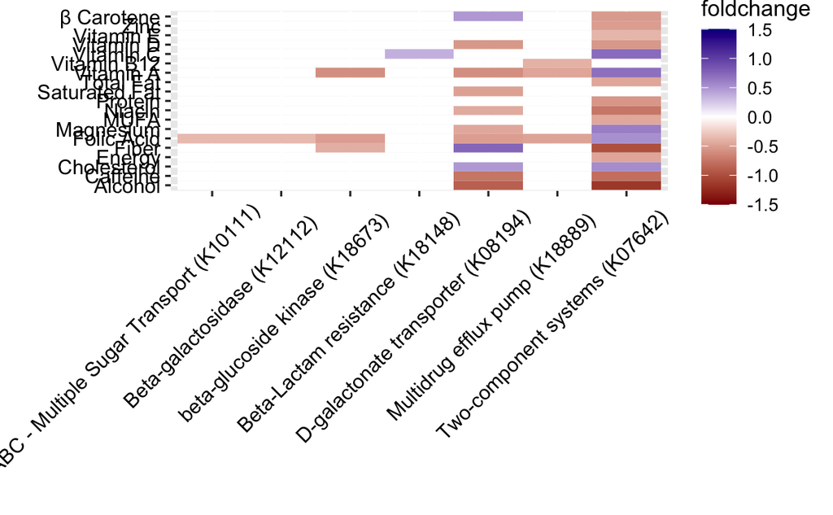

```r
# Make the dataframe
########################################################################
KO_parameter_fitzig <- data.frame(Alc_sig,VB12_sig,VB6_sig,β.Car_sig,Caff_sig,Carb_sig,Chol_sig,Energy_sig,
  T.fat_sig,Fib_sig,Folic_sig,Iron_sig,Mag_sig,MUFA_sig,Nicain_sig,Protein_sig,
  PUFA_sig,Ribo_sig,SatFat_sig,Selenium_sig,Thiamin_sig,Trans.fat_sig,Vitamin.A_sig,
  Vitamin.C_sig,Vitamin.D_sig,Vitamin.E_sig,Zinc_sig)


# Add KO names
########################################################################
rownames(KO_parameter_fitzig) <- c(
          "Two-component systems (K07642)",
          "D-galactonate transporter (K08194)",
          "beta-glucoside kinase (K18673)",
          "Multidrug efflux pump (K18889)",
          "Beta-Lactam resistance (K18148)",
          "ABC - Cellobiose transport (K10240)",
          "ABC - Cellobiose transport (K10241)",
          "ABC - Multiple Sugar Transport (K10111)",
          "Beta-galactosidase (K12112)",
          "Sialic acid transporter (K03290)",
          "DNA-binding protein (K05787)",
          "ABC - Diacetylchitobiose transport (K17329)",
          "ABC - Diacetylchitobiose transport (K17330)",
          "Formate transporter (K06212)",
          "NAD(P)H dehydrogenase (quinone) (K03809)")


# Rename Columns
########################################################################
KO_parameter_fitzig <- KO_parameter_fitzig %>% rename("Alcohol" = Alc_sig,
                                                      "Vitamin B12" = VB12_sig,
                                                      "Vitamin B6" = VB6_sig,
                                                      "β Carotene" = β.Car_sig,
                                                      "Caffeine" = Caff_sig,
                                                      "Carbohydrate" = Carb_sig,
                                                      "Cholesterol" = Chol_sig,
                                                      "Energy" = Energy_sig,
                                                      "Total Fat" = T.fat_sig,
                                                      "Fiber" = Fib_sig,
                                                      "Folic Acid" = Folic_sig,
                                                      "Iron" = Iron_sig,
                                                      "Magnesium" = Mag_sig,
                                                      "MUFA" = MUFA_sig,
                                                      "Niacin" = Nicain_sig,
                                                      "Protein" = Protein_sig,
                                                      "PUFA" = PUFA_sig,
                                                      "Riboflavin" = Ribo_sig,
                                                      "Saturated Fat" = SatFat_sig,
                                                      "Selenium" = Selenium_sig,
                                                      "Thiamin" = Thiamin_sig,
                                                      "Transaturated Fat" = Trans.fat_sig,
                                                      "Vitamin A" = Vitamin.A_sig,
                                                      "Vitamin C" = Vitamin.C_sig,
                                                      "Vitamin D" = Vitamin.D_sig,
                                                      "Vitamin E" = Vitamin.E_sig,
                                                      "Zinc" = Zinc_sig)

#Drop columns that sum to 0
KO_parameter_fitzig <-  KO_parameter_fitzig[, colSums(KO_parameter_fitzig != 0) > 0]
KO_parameter_fitzig <-  KO_parameter_fitzig[rowSums(KO_parameter_fitzig != 0) > 0,]

KO_parameter_plotting <- KO_parameter_fitzig %>%
  rownames_to_column() %>%
  gather(colname, value, -rowname)

KO_parameter_plotting <- KO_parameter_plotting %>% rename("foldchange" = "value")

# Make the Plot
########################################################################
ggplot(KO_parameter_plotting, aes(x = rowname, y = colname, fill = foldchange)) +
  geom_tile() +
  scale_fill_gradient2(high="darkblue", low="darkred", midpoint=0,
                        limits=c(-1.5,1.5)) +
  theme(axis.text.x = element_text(size =10, angle = 45, vjust= 0.85, hjust= 0.85, colour="black"),
        axis.text.y = element_text(size =10, colour="black")) +
  xlab("") +
  ylab("")
```

##### 3.4.2.2 - Gene Set Enrichment Analysis

Running a gene set enrichment analysis on the identified KOs from the 0-inflated model. For this, we used MicrobiomeProfiler. To do so, take the terms that were differential increased as opposed to enriched in terms of DII.

**Notes on Installation**  
Make sure its the correct bioconductor version

**Run Microbiome Profiler**

```r
#Launch the HTML
#run_MicrobiomeProfiler()
```

**Make Plot of Results**  
Saved the results from MicrobiomeProfiler to an excel file for easy plotting. Note: used the FDR enriched KO lists

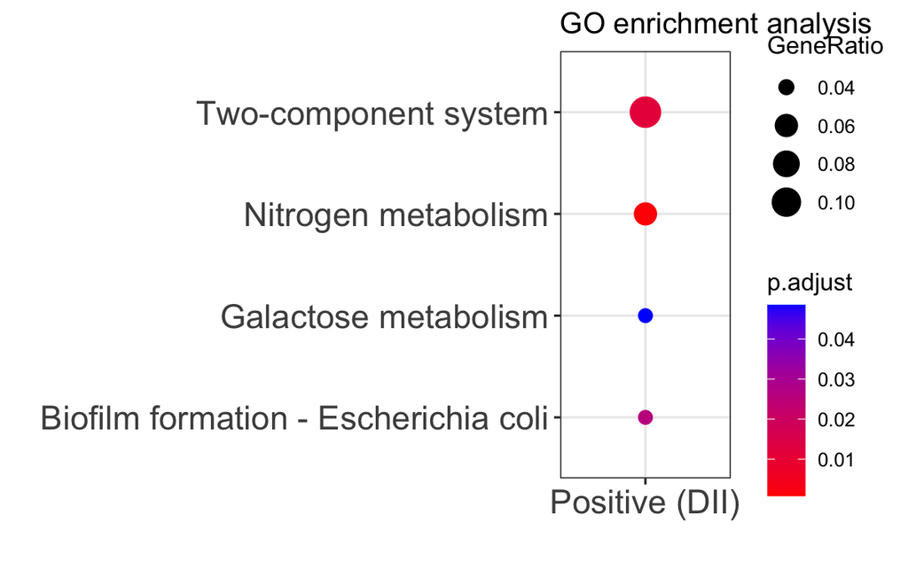

```r
#Step 1: Read in the Data
################################################################
GSEA_data <- read_excel(here("Output", "GSEA_Output", "GSEA_Results.xlsx"))

#Relabel the ratios for plotting
GSEA_data$GeneRatio <- c(6/101, 12/101, 4/101, 4/101)


#Step 2: Plot
################################################################
ggplot(data = GSEA_data, aes(x = Condition, y = Term,
                        color = `p.adjust`, size = GeneRatio)) +
  geom_point() +
  scale_color_gradient(low = "red", high = "blue") +
  scale_size_continuous(range = c(2.5, 6)) +
  theme_bw() +
  ylab("") +
  xlab("") +
  ggtitle("GO enrichment analysis") +
  theme(axis.text = element_text(size = 15))
```

### 3.5 K-Means of KOs

**Use all KOs that were signficant before p-value correction**

Data Prep

```r
# Step 1: Filter KO Count table by KOs used in GSEA
##########################################################
KOs_Networks <- KO_SID_table %>% subset(rownames(KO_SID_table) %in% rownames(MR_coefs_GSEA))

# Reorganize the table
KOs_Networks <- t(KOs_Networks)


# Step 2: Splir into two groups
##########################################################
Group1_ids <- rownames(info)[info$group=="Tertile 1"]

Group2_ids <- rownames(info)[info$group=="Tertile 2/3"]

#Group 1 (Tertile 1)
KO_net_g1 <- KOs_Networks %>% subset(rownames(KOs_Networks) %in% Group1_ids)

#Group 2 (Tertile 2/3)
KO_net_g2 <- KOs_Networks %>% subset(rownames(KOs_Networks) %in% Group2_ids)
```

K-means

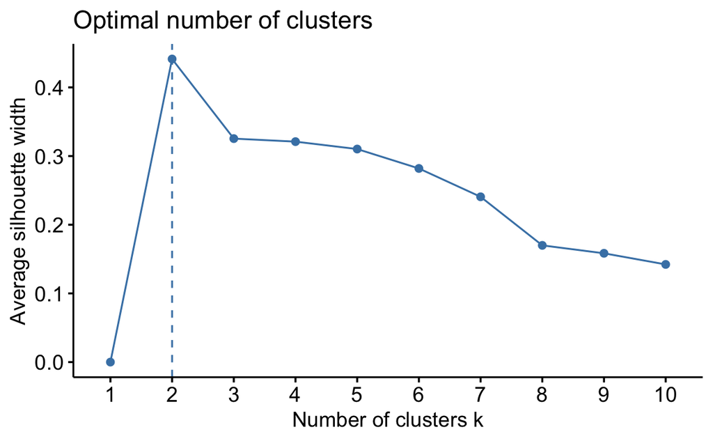

```r
# Elbow Plot for bet clusters
#########################################################
 fviz_nbclust(KOs_Networks, FUNcluster = kmeans, method = "silhouette")
```

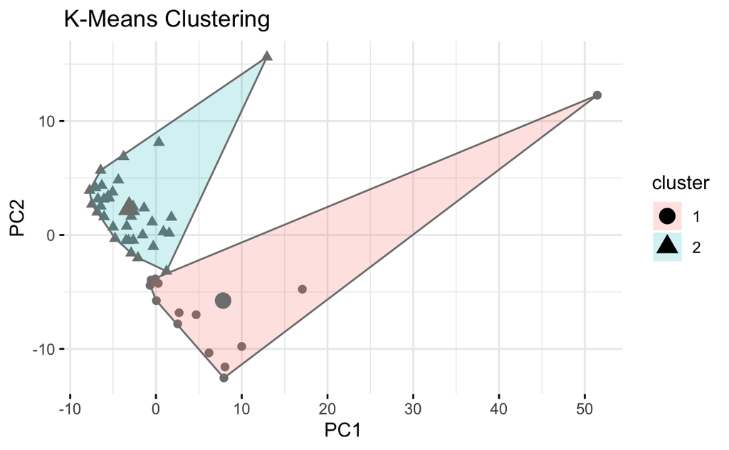

```r
# K-means clustering
#########################################################
kmeans_result <- kmeans(KOs_Networks, centers = 2)

# Plot K-means
#########################################################
KOs_Networks2 <- as.data.frame(KOs_Networks)
KOs_Networks2$DII<- info$DII

fviz_cluster(kmeans_result, data = KOs_Networks2,
              geom = "point",
              ellipse.type = "convex",
              ggtheme = theme_minimal(),
              show.clust.cent = TRUE,
              ellipse.alpha = 0.2,
              pointsize = 2) +
   labs(title = "K-Means Clustering",
        #subtitle = "Clustered by DII",
        x = "PC1",
        y = "PC2") +
   scale_color_manual(values = c("Cluster 1" = "red", "Cluster 2" = "blue"))
```

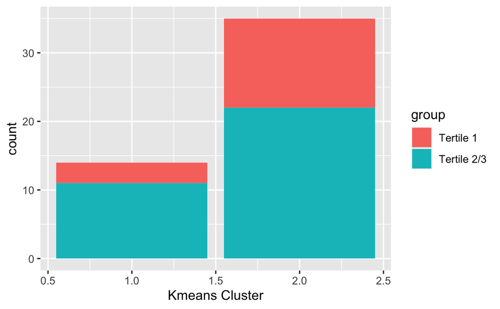

```r
# Compare to tertile
#########################################################
#Add cluster info to dataframe
clusters <- as.data.frame(kmeans_result[["cluster"]])
info_clusters <- merge(info, clusters, by = 0, all=TRUE)

#Plot
ggplot(info_clusters) +
  aes(x = `kmeans_result[["cluster"]]`, fill = group) +
  geom_bar() +
  xlab("Kmeans Cluster")
```

```r
#Chi-square
chisq.test(table(info_clusters$`kmeans_result[["cluster"]]`, info_clusters$group))
```

```
    Pearson's Chi-squared test with Yates' continuity correction

data:  table(info_clusters$`kmeans_result[["cluster"]]`, info_clusters$group)
X-squared = 0.52202, df = 1, p-value = 0.47
```